# Non-comparative Analysis

Anon

Revised 2026-08-25

# NOTE

Identification has been renamed to “Find” tasks Estimation has been renamed to “Lookup” tasks

## Data Cleaning

```r
library(plyr)
library(tidyverse)
library(readxl)
library(purrr)
library(lme4)
library(ggpubr)
library(emmeans)
library(glmmTMB)
library(robustlmm)
library(ggdist)
```

```r
data <- read_csv("NonThresholdData.csv")
data.clean <- data |>
  filter(Finished == "TRUE") |>
  mutate(StartDate = as.Date(StartDate, "%m/%d/%y")) |>
  filter(StartDate >= ymd("2024-09-15")) |>
  select(-contains("Click"))
```

### Answers

Read in the answer key and build `answerKey_list`: a list where names are values of `dist` from the data and values are a vector of valid answers for that `dist`:

```r
answerKey <- read_xlsx("AnswerKeyNonThreshold.xlsx")

list_questions = c("7", "8", "9", "10", "11", "12", "31", "32", "33", "34", "35", "36")
nonlist_questions = setdiff(names(answerKey), list_questions)

answerKey_list = as.list(answerKey)
answerKey_list[list_questions] = answerKey_list[list_questions] |>
  unlist() |>
  strsplit(",") |>
  map(as.numeric)

stopifnot(
  length(answerKey) == length(answerKey_list),
  !is.na(answerKey_list),
  lengths(answerKey_list[list_questions]) == 5,
  lengths(answerKey_list[nonlist_questions]) == 1
)

str(answerKey_list)
```

```
## List of 37
##  $ 1 : num 4
##  $ 2 : num 12
##  $ 3 : num 4
##  $ 4 : num 7
##  $ 5 : num 1
##  $ 6 : num 2
##  $ 7 : num [1:5] 3 5 8 13 15
##  $ 8 : num [1:5] 1 2 10 11 14
##  $ 9 : num [1:5] 2 5 6 11 12
##  $ 10: num [1:5] 5 11 13 14 16
##  $ 11: num [1:5] 2 6 7 9 10
##  $ 12: num [1:5] 7 11 13 14 16
##  $ 13: num 47
##  $ 14: num 32
```

[output cut: 23 more lines]

Restructure the data into a long format with `graph` (graph type), `question`, and `Answer` (vector of answers provided by the participant to that question):

```r
data.clean.answers = data.clean |>
  pivot_longer(
    cols = c(`ControlIdeCurVal1_Page Submit`:SepPosEstTrend23),
    names_to = "question",
    values_to = "value"
  ) |>
  filter(!is.na(value)) |>
  mutate(
    type = if_else(str_detect(question, "_Page Submit"), "time", "Answer"),
    graph = case_when(
      str_detect(question, "Control") ~ "Control",
      str_detect(question, "Emphasis") ~ "Emphasis",
      str_detect(question, "IntSize") ~ "IntSize",
      str_detect(question, "IntPos") ~ "IntPos",
      str_detect(question, "SepSize") ~ "SepSize",
      str_detect(question, "SepPos") ~ "SepPos",
      str_detect(question, "Attention") ~ "AttentionCheck",
      .unmatched = "error"
    ),
    qtype = case_when(
      str_detect(question, "Ide(nt)?CurVal[^L]") ~ "IdentCurVal",
      str_detect(question, "IdeCurValL") ~ "IdentCurValL",
      str_detect(question, "IdeTrend[^L]")  ~ "IdentTrend",
      str_detect(question, "IdeTrendL") ~ "IdentTrendL",
      str_detect(question, "EstCurVal") ~ "EstCurVal",
      str_detect(question, "EstTrend") ~ "EstTrend",
      str_detect(question, "Attention") ~ "AttentionCheck",
      .unmatched = "error"
    ),
    dist = str_extract(question, "[0-9]+")
  ) |>
  select(-question) |>
  pivot_wider(values_from = value, names_from = type) |>
  rename(question = qtype) |>
  mutate(
    dist = if_else(is.na(dist), "A", dist),
    Answer = strsplit(Answer, ",")
  )

data.clean.answers |>
  mutate(count = lengths(Answer)) |>
  summarise(min_n = min(count), max_n = max(count), .by = question) |>
  with(stopifnot(min_n == max_n, setequal(min_n, c(1, 3))))

data.clean.answers
```

```
## # A tibble: 1,998 × 48
##    StartDate  EndDate      Progress Duration (in seconds…¹ Finished RecordedDate
##    <date>     <chr>        <chr>    <chr>                  <chr>    <chr>
##  1 2024-09-15 9/15/24 15:… 100      640                    TRUE     9/15/24 15:…
##  2 2024-09-15 9/15/24 15:… 100      640                    TRUE     9/15/24 15:…
##  3 2024-09-15 9/15/24 15:… 100      640                    TRUE     9/15/24 15:…
##  4 2024-09-15 9/15/24 15:… 100      640                    TRUE     9/15/24 15:…
##  5 2024-09-15 9/15/24 15:… 100      640                    TRUE     9/15/24 15:…
##  6 2024-09-15 9/15/24 15:… 100      640                    TRUE     9/15/24 15:…
##  7 2024-09-15 9/15/24 15:… 100      640                    TRUE     9/15/24 15:…
##  8 2024-09-15 9/15/24 15:… 100      640                    TRUE     9/15/24 15:…
##  9 2024-09-15 9/15/24 15:… 100      640                    TRUE     9/15/24 15:…
## 10 2024-09-15 9/15/24 15:… 100      640                    TRUE     9/15/24 15:…
## # ℹ 1,988 more rows
## # ℹ abbreviated name: ¹`Duration (in seconds)`
## # ℹ 42 more variables: ResponseId <chr>, DistributionChannel <chr>,
## #   UserLanguage <chr>, AssistiveTech <chr>, DeviceAndFullScreen <chr>,
## #   StandardTrain1 <chr>, EmphasisTrain1 <chr>, IntegratedSizeTrain1 <chr>,
## #   IntegratedPosTrain1 <chr>, SeparatedSizeTrain1 <chr>,
## #   SeparatedPosTrain1 <chr>, IdentCurValLTrain1 <chr>, …
```

Code answers for correctness by checking each participant’s `Answer` set on each question against the corresponding set from `answerKey_list`.

```r
data.clean.answerscoded.raw = data.clean.answers |>
  mutate(
    actualAns = answerKey_list[dist],
    correctAns = map2(Answer, actualAns, intersect),
    ans_TF = lengths(correctAns) == lengths(Answer)
  ) |>
  rename(
    "IntSize Ratings" = Q51,
    "IntPos Ratings" = Q53,
    "SepSize Ratings" = Q52,
    "SepPos Ratings" = Q50,
    "QualitativeResponseWhy" = Q177
  ) |>
  select(StartDate:`Est Trend`, graph, question, dist, time, actualAns, ans_TF) |>
  mutate(
    time = as.numeric(time),
    logTime = log(time)
  )

data.clean.answerscoded.raw
```

```
## # A tibble: 1,998 × 50
##    StartDate  EndDate      Progress Duration (in seconds…¹ Finished RecordedDate
##    <date>     <chr>        <chr>    <chr>                  <chr>    <chr>
##  1 2024-09-15 9/15/24 15:… 100      640                    TRUE     9/15/24 15:…
##  2 2024-09-15 9/15/24 15:… 100      640                    TRUE     9/15/24 15:…
##  3 2024-09-15 9/15/24 15:… 100      640                    TRUE     9/15/24 15:…
##  4 2024-09-15 9/15/24 15:… 100      640                    TRUE     9/15/24 15:…
##  5 2024-09-15 9/15/24 15:… 100      640                    TRUE     9/15/24 15:…
##  6 2024-09-15 9/15/24 15:… 100      640                    TRUE     9/15/24 15:…
##  7 2024-09-15 9/15/24 15:… 100      640                    TRUE     9/15/24 15:…
##  8 2024-09-15 9/15/24 15:… 100      640                    TRUE     9/15/24 15:…
##  9 2024-09-15 9/15/24 15:… 100      640                    TRUE     9/15/24 15:…
## 10 2024-09-15 9/15/24 15:… 100      640                    TRUE     9/15/24 15:…
## # ℹ 1,988 more rows
## # ℹ abbreviated name: ¹`Duration (in seconds)`
## # ℹ 44 more variables: ResponseId <chr>, DistributionChannel <chr>,
## #   UserLanguage <chr>, AssistiveTech <chr>, DeviceAndFullScreen <chr>,
## #   StandardTrain1 <chr>, EmphasisTrain1 <chr>, IntegratedSizeTrain1 <chr>,
## #   IntegratedPosTrain1 <chr>, SeparatedSizeTrain1 <chr>,
## #   SeparatedPosTrain1 <chr>, IdentCurValLTrain1 <chr>, …
```

### Participant removal

Flags for participants to remove from the original data cleaning script:

```r
data.clean.answerscoded.numCorrect <- data.clean.answerscoded.raw %>%
  filter(dist != "A") %>%
  group_by(ResponseId) %>%
  mutate(NumCorrect = sum(ans_TF)) %>%
  distinct(ResponseId, NumCorrect)

#Check for anyone outside of 2 standard deviations from the mean of number correct
cutoff <- mean(data.clean.answerscoded.numCorrect$NumCorrect) -
  2*sd(data.clean.answerscoded.numCorrect$NumCorrect)

data.clean.answerscoded.numCorrect.remove <- data.clean.answerscoded.numCorrect %>%
  filter(NumCorrect < cutoff) %>% pull(ResponseId)

data.clean.answerscoded.AC <- data.clean.answerscoded.raw %>%
  filter(dist == "A") %>%
  #This is a slightly incorrect way to do this, based on some of the rewrite of the code:
  #Many participants got this incorrect, however this answer was the answer to
  #the question block. Because every participant answered either 1 or 16, we left them in
  #With the rewrite of the code, all of them were assigned the correct answer here
  #Which makes this redundant
  filter(actualAns == 16 | actualAns == 1) %>%
  pull(ResponseId)
```

Remove participants:

```r
data.clean.answerscoded <- data.clean.answerscoded.raw %>%
  filter(!(ResponseId %in% data.clean.answerscoded.numCorrect.remove)) %>%
  filter(ResponseId %in% data.clean.answerscoded.AC)
```

```r
data.clean %>% dplyr::count(Age)
```

```
## # A tibble: 6 × 2
##   Age                 n
##   <chr>           <int>
## 1 18-24 years old    10
## 2 25-34 years old    21
## 3 35-44 years old     8
## 4 45-54 years old     9
## 5 55-64 years old     3
## 6 65+ years old       3
```

```r
data.clean %>% dplyr::count(Gender)
```

```
## # A tibble: 3 × 2
##   Gender                        n
##   <chr>                     <int>
## 1 Female                       25
## 2 Male                         28
## 3 Non-binary / third gender     1
```

```r
data.clean %>% dplyr::count(Race)
```

```
## # A tibble: 7 × 2
##   Race                                                   n
##   <chr>                                              <int>
## 1 Asian                                                  4
## 2 Black or African American                              7
## 3 Other                                                  2
## 4 White or Caucasian                                    38
## 5 White or Caucasian,Asian                               1
## 6 White or Caucasian,Black or African American           1
## 7 White or Caucasian,Black or African American,Other     1
```

```r
data.clean %>% dplyr::count(`Hispanic/Latino`)
```

```
## # A tibble: 2 × 2
##   `Hispanic/Latino`     n
##   <chr>             <int>
## 1 No                   52
## 2 Yes                   2
```

```r
data.clean %>% dplyr::count(Q179)
```

```
## # A tibble: 2 × 2
##   Q179                    n
##   <chr>               <int>
## 1 Corrected to normal    29
## 2 Normal                 25
```

```r
data.clean.answerscoded.outliers = data.clean.answerscoded |>
  filter(question != "AttentionCheck") |>
  mutate(
    .by = question,
    time_IQR = IQR(time),
    time_upper = quantile(time, probs = .75, na.rm = FALSE) + 1.5 * time_IQR,
    time_lower = quantile(time, probs = .25, na.rm = FALSE) - 1.5 * time_IQR,
    outlier = time > time_upper | time < time_lower
  ) |>
  # reorder designs and questions
  mutate(
    graph = graph |> fct_relevel(
      "Control",
      "Emphasis",
      "IntSize",
      "IntPos",
      "SepSize",
      "SepPos"
    ),
    question = question |> fct_relevel(
      "IdentCurVal",
      "IdentCurValL",
      "IdentTrend",
      "IdentTrendL",
      "EstCurVal",
      "EstTrend"
    )
  )
```

```r
overallModel <-
  glmmTMB(logTime ~ graph + (1 | ResponseId),
        dispformula = ~ graph,
        family = glmmTMB::t_family,
        data = data.clean.answerscoded.outliers %>% filter(outlier == FALSE),
        start = list(psi = log(4)),   # fix df to 4
        map = list(psi = factor(NA)))

summary(overallModel)
```

```
##  Family: t  ( identity )
## Formula:          logTime ~ graph + (1 | ResponseId)
## Dispersion:               ~graph
## Data: data.clean.answerscoded.outliers %>% filter(outlier == FALSE)
##
##       AIC       BIC    logLik -2*log(L)  df.resid
##    2028.5    2099.0   -1001.3    2002.5      1656
##
## Random effects:
##
## Conditional model:
##  Groups     Name        Variance Std.Dev.
##  ResponseId (Intercept) 0.04062  0.2015
## Number of obs: 1669, groups:  ResponseId, 49
##
## Conditional model:
##               Estimate Std. Error z value Pr(>|z|)
## (Intercept)    2.19619    0.03814   57.58   <2e-16 ***
## graphEmphasis -0.01859    0.03552   -0.52   0.6006
## graphIntSize  -0.07444    0.03545   -2.10   0.0357 *
## graphIntPos   -0.03337    0.03612   -0.92   0.3555
## graphSepSize  -0.03916    0.03599   -1.09   0.2767
## graphSepPos    0.04558    0.03580    1.27   0.2030
## ---
## Signif. codes:  0 '***' 0.001 '**' 0.01 '*' 0.05 '.' 0.1 ' ' 1
##
## Dispersion model:
##               Estimate Std. Error z value Pr(>|z|)
## (Intercept)   -1.08358    0.05354 -20.238   <2e-16 ***
## graphEmphasis  0.02996    0.07615   0.393    0.694
## graphIntSize   0.02296    0.07542   0.304    0.761
## graphIntPos    0.05820    0.07547   0.771    0.441
## graphSepSize   0.06921    0.07570   0.914    0.361
## graphSepPos    0.04270    0.07589   0.563    0.574
## ---
## Signif. codes:  0 '***' 0.001 '**' 0.01 '*' 0.05 '.' 0.1 ' ' 1
```

```r
models = data.clean.answerscoded.outliers |>

  # Remove outliers
  filter(outlier == FALSE) |>

  # Group by qurstions
  group_by(question) |>
  group_modify(\(data, groups) {
    model = glmmTMB(
        logTime ~ graph + (1 | ResponseId),
        dispformula = ~ graph,
        family = glmmTMB::t_family,
        data = data,
        start = list(psi = log(4)),   # fix df to 4
        map = list(psi = factor(NA))
      )

    basemodel = glmmTMB(
        logTime ~ (1 | ResponseId),
        family = glmmTMB::t_family,
        data = data,
        start = list(psi = log(4)),   # fix df to 4
        map = list(psi = factor(NA))
      )

    # Estimate contrasts between all pairs of conditions with multiple
    # comparison correction. We use "revpairwise" instead of "pairwise" to get
    # the same comparison direction as presented in the paper:
    # (treatment - control) instead of (control - treatment).
    estimates = model |>
      emmeans(~ graph) |>
      contrast(method = "revpairwise")

    # Get confidence intervals on estimates
    intervals = confint(estimates) |>
      # lmer and glmmTMB use different column names for intervals; normalize them
      rename(any_of(c(
        lower = "asymp.LCL", lower = "lower.CL",
        upper = "asymp.UCL", upper = "upper.CL"
      )))

    # The use of tibble() + list() here creates a data frame with nested
    # "list columns", which can contain complex objects like models or even
    # other data frames. This allows us to easily create a single dataframe
    # for visualizing specific things (like intervals) later using unnest().
    tibble(
      model = list(model),
      basemodel = list(basemodel),
      estimates = list(estimates),
      intervals = list(intervals)
    )
  }) |>
  ungroup()

models
```

```
## # A tibble: 6 × 5
##   question     model     basemodel estimates intervals
##   <fct>        <list>    <list>    <list>    <list>
## 1 IdentCurVal  <glmmTMB> <glmmTMB> <emmGrid> <smmry_mm [15 × 6]>
## 2 IdentCurValL <glmmTMB> <glmmTMB> <emmGrid> <smmry_mm [15 × 6]>
## 3 IdentTrend   <glmmTMB> <glmmTMB> <emmGrid> <smmry_mm [15 × 6]>
## 4 IdentTrendL  <glmmTMB> <glmmTMB> <emmGrid> <smmry_mm [15 × 6]>
## 5 EstCurVal    <glmmTMB> <glmmTMB> <emmGrid> <smmry_mm [15 × 6]>
## 6 EstTrend     <glmmTMB> <glmmTMB> <emmGrid> <smmry_mm [15 × 6]>
```

```r
models$model[[1]]
```

```
## Formula:          logTime ~ graph + (1 | ResponseId)
## Dispersion:               ~graph
## Data: data
##       AIC       BIC    logLik -2*log(L)  df.resid
##  43.01658  90.45324  -8.50829  17.01658       271
## Random-effects (co)variances:
##
## Conditional model:
##  Groups     Name        Std.Dev.
##  ResponseId (Intercept) 0.2059
##
## Number of obs: 284 / Conditional model: ResponseId, 48
##
## Student-t df estimate:    4
##
## Fixed Effects:
##
## Conditional model:
##   (Intercept)  graphEmphasis   graphIntSize    graphIntPos   graphSepSize
##       2.29847       -0.09068       -0.27531       -0.15979       -0.23730
##   graphSepPos
##      -0.06051
##
## Dispersion model:
##   (Intercept)  graphEmphasis   graphIntSize    graphIntPos   graphSepSize
##     -1.898883       0.003055       0.128664       0.035604       0.200044
##   graphSepPos
##      0.300083
```

```r
# joint_tests(models$model[[1]])
# car::Anova(models$model[[1]])

models$estimates[[1]]
```

```
##  contrast           estimate     SE  df z.ratio p.value
##  Emphasis - Control  -0.0907 0.0383 Inf  -2.367  0.1679
##  IntSize - Control   -0.2753 0.0406 Inf  -6.780 <0.0001
##  IntSize - Emphasis  -0.1846 0.0416 Inf  -4.442  0.0001
##  IntPos - Control    -0.1598 0.0386 Inf  -4.138  0.0005
##  IntPos - Emphasis   -0.0691 0.0386 Inf  -1.792  0.4708
##  IntPos - IntSize     0.1155 0.0416 Inf   2.774  0.0617
##  SepSize - Control   -0.2373 0.0419 Inf  -5.657 <0.0001
##  SepSize - Emphasis  -0.1466 0.0426 Inf  -3.440  0.0077
##  SepSize - IntSize    0.0380 0.0444 Inf   0.855  0.9568
##  SepSize - IntPos    -0.0775 0.0428 Inf  -1.810  0.4592
##  SepPos - Control    -0.0605 0.0450 Inf  -1.344  0.7601
##  SepPos - Emphasis    0.0302 0.0452 Inf   0.668  0.9854
##  SepPos - IntSize     0.2148 0.0477 Inf   4.508 <0.0001
##  SepPos - IntPos      0.0993 0.0455 Inf   2.183  0.2454
##  SepPos - SepSize     0.1768 0.0484 Inf   3.654  0.0035
##
## P value adjustment: tukey method for comparing a family of 6 estimates
```

```r
models$intervals[[1]]
```

```
##  contrast           estimate     SE  df    lower   upper
##  Emphasis - Control  -0.0907 0.0383 Inf -0.19986  0.0185
##  IntSize - Control   -0.2753 0.0406 Inf -0.39101 -0.1596
##  IntSize - Emphasis  -0.1846 0.0416 Inf -0.30307 -0.0662
##  IntPos - Control    -0.1598 0.0386 Inf -0.26985 -0.0497
##  IntPos - Emphasis   -0.0691 0.0386 Inf -0.17900  0.0408
##  IntPos - IntSize     0.1155 0.0416 Inf -0.00317  0.2342
##  SepSize - Control   -0.2373 0.0419 Inf -0.35684 -0.1178
##  SepSize - Emphasis  -0.1466 0.0426 Inf -0.26807 -0.0252
##  SepSize - IntSize    0.0380 0.0444 Inf -0.08859  0.1646
##  SepSize - IntPos    -0.0775 0.0428 Inf -0.19955  0.0445
##  SepPos - Control    -0.0605 0.0450 Inf -0.18878  0.0678
##  SepPos - Emphasis    0.0302 0.0452 Inf -0.09856  0.1589
##  SepPos - IntSize     0.2148 0.0477 Inf  0.07900  0.3506
##  SepPos - IntPos      0.0993 0.0455 Inf -0.03029  0.2289
##  SepPos - SepSize     0.1768 0.0484 Inf  0.03890  0.3147
##
## Confidence level used: 0.95
## Conf-level adjustment: tukey method for comparing a family of 6 estimates
```

```r
print(models$question[[1]])
```

```
## [1] IdentCurVal
## 6 Levels: IdentCurVal IdentCurValL IdentTrend IdentTrendL ... EstTrend
```

```r
models$model[[1]]
```

```
## Formula:          logTime ~ graph + (1 | ResponseId)
## Dispersion:               ~graph
## Data: data
##       AIC       BIC    logLik -2*log(L)  df.resid
##  43.01658  90.45324  -8.50829  17.01658       271
## Random-effects (co)variances:
##
## Conditional model:
##  Groups     Name        Std.Dev.
##  ResponseId (Intercept) 0.2059
##
## Number of obs: 284 / Conditional model: ResponseId, 48
##
## Student-t df estimate:    4
##
## Fixed Effects:
##
## Conditional model:
##   (Intercept)  graphEmphasis   graphIntSize    graphIntPos   graphSepSize
##       2.29847       -0.09068       -0.27531       -0.15979       -0.23730
##   graphSepPos
##      -0.06051
##
## Dispersion model:
##   (Intercept)  graphEmphasis   graphIntSize    graphIntPos   graphSepSize
##     -1.898883       0.003055       0.128664       0.035604       0.200044
##   graphSepPos
##      0.300083
```

```r
print(models$question[[2]])
```

```
## [1] IdentCurValL
## 6 Levels: IdentCurVal IdentCurValL IdentTrend IdentTrendL ... EstTrend
```

```r
models$model[[2]]
```

```
## Formula:          logTime ~ graph + (1 | ResponseId)
## Dispersion:               ~graph
## Data: data
##       AIC       BIC    logLik -2*log(L)  df.resid
## -28.65307  18.27006  27.32654 -54.65307       260
## Random-effects (co)variances:
##
## Conditional model:
##  Groups     Name        Std.Dev.
##  ResponseId (Intercept) 0.1986
##
## Number of obs: 273 / Conditional model: ResponseId, 48
##
## Student-t df estimate:    4
##
## Fixed Effects:
##
## Conditional model:
##   (Intercept)  graphEmphasis   graphIntSize    graphIntPos   graphSepSize
##       2.26059       -0.08636       -0.12676       -0.10740       -0.10113
##   graphSepPos
##       0.07697
##
## Dispersion model:
##   (Intercept)  graphEmphasis   graphIntSize    graphIntPos   graphSepSize
##       -2.4759         0.3888         0.6785         0.6407         0.7188
##   graphSepPos
##        0.7475
```

```r
print(models$question[[3]])
```

```
## [1] IdentTrend
## 6 Levels: IdentCurVal IdentCurValL IdentTrend IdentTrendL ... EstTrend
```

```r
models$model[[3]]
```

```
## Formula:          logTime ~ graph + (1 | ResponseId)
## Dispersion:               ~graph
## Data: data
##       AIC       BIC    logLik -2*log(L)  df.resid
##  60.67330 107.97191 -17.33665  34.67330       268
## Random-effects (co)variances:
##
## Conditional model:
##  Groups     Name        Std.Dev.
##  ResponseId (Intercept) 0.259
##
## Number of obs: 281 / Conditional model: ResponseId, 49
##
## Student-t df estimate:    4
##
## Fixed Effects:
##
## Conditional model:
##   (Intercept)  graphEmphasis   graphIntSize    graphIntPos   graphSepSize
##       2.53151        0.10167        0.08685        0.12713        0.19277
##   graphSepPos
##       0.18054
##
## Dispersion model:
##   (Intercept)  graphEmphasis   graphIntSize    graphIntPos   graphSepSize
##     -1.783303      -0.050249      -0.022726       0.003593       0.148832
##   graphSepPos
##     -0.140595
```

```r
print(models$question[[4]])
```

```
## [1] IdentTrendL
## 6 Levels: IdentCurVal IdentCurValL IdentTrend IdentTrendL ... EstTrend
```

```r
models$model[[4]]
```

```
## Formula:          logTime ~ graph + (1 | ResponseId)
## Dispersion:               ~graph
## Data: data
##       AIC       BIC    logLik -2*log(L)  df.resid
##   7.33520  54.30587   9.33240 -18.66480       261
## Random-effects (co)variances:
##
## Conditional model:
##  Groups     Name        Std.Dev.
##  ResponseId (Intercept) 0.2314
##
## Number of obs: 274 / Conditional model: ResponseId, 49
##
## Student-t df estimate:    4
##
## Fixed Effects:
##
## Conditional model:
##   (Intercept)  graphEmphasis   graphIntSize    graphIntPos   graphSepSize
##      2.474789      -0.006970      -0.004051       0.045626       0.033311
##   graphSepPos
##     -0.024275
##
## Dispersion model:
##   (Intercept)  graphEmphasis   graphIntSize    graphIntPos   graphSepSize
##      -1.81094       -0.09704       -0.06176       -0.05549       -0.07685
##   graphSepPos
##      -0.21015
```

```r
print(models$question[[5]])
```

```
## [1] EstCurVal
## 6 Levels: IdentCurVal IdentCurValL IdentTrend IdentTrendL ... EstTrend
```

```r
models$model[[5]]
```

```
## Formula:          logTime ~ graph + (1 | ResponseId)
## Dispersion:               ~graph
## Data: data
##       AIC       BIC    logLik -2*log(L)  df.resid
## -55.00537  -7.98734  40.50268 -81.00537       262
## Random-effects (co)variances:
##
## Conditional model:
##  Groups     Name        Std.Dev.
##  ResponseId (Intercept) 0.248
##
## Number of obs: 275 / Conditional model: ResponseId, 49
##
## Student-t df estimate:    4
##
## Fixed Effects:
##
## Conditional model:
##   (Intercept)  graphEmphasis   graphIntSize    graphIntPos   graphSepSize
##      1.696050      -0.005694       0.015264      -0.030216       0.084593
##   graphSepPos
##     -0.011016
##
## Dispersion model:
##   (Intercept)  graphEmphasis   graphIntSize    graphIntPos   graphSepSize
##     -1.902486       0.007657      -0.353217      -0.180435      -0.136251
##   graphSepPos
##     -0.203308
```

```r
print(models$question[[6]])
```

```
## [1] EstTrend
## 6 Levels: IdentCurVal IdentCurValL IdentTrend IdentTrendL ... EstTrend
```

```r
models$model[[6]]
```

```
## Formula:          logTime ~ graph + (1 | ResponseId)
## Dispersion:               ~graph
## Data: data
##       AIC       BIC    logLik -2*log(L)  df.resid
##  86.52510 133.86989 -30.26255  60.52510       269
## Random-effects (co)variances:
##
## Conditional model:
##  Groups     Name        Std.Dev.
##  ResponseId (Intercept) 0.2725
##
## Number of obs: 282 / Conditional model: ResponseId, 49
##
## Student-t df estimate:    4
##
## Fixed Effects:
##
## Conditional model:
##   (Intercept)  graphEmphasis   graphIntSize    graphIntPos   graphSepSize
##     1.7894024     -0.0267710      0.0540563      0.0413108      0.0009176
##   graphSepPos
##     0.0925158
##
## Dispersion model:
##   (Intercept)  graphEmphasis   graphIntSize    graphIntPos   graphSepSize
##    -1.9646049     -0.0003869      0.2157978      0.3735613      0.3267866
##   graphSepPos
##     0.2272990
```

```r
paste0("Estimate of ",  models$question[[1]], ": ", round(exp(2.29847), digits = 1))
```

```
## [1] "Estimate of IdentCurVal: 10"
```

```r
paste0("Estimate of ",  models$question[[2]], ": ", round(exp(2.26059), digits = 1))
```

```
## [1] "Estimate of IdentCurValL: 9.6"
```

```r
paste0("Estimate of ",  models$question[[3]], ": ", round(exp(2.53151), digits = 1))
```

```
## [1] "Estimate of IdentTrend: 12.6"
```

```r
paste0("Estimate of ",  models$question[[4]], ": ", round(exp(2.474789), digits = 1))
```

```
## [1] "Estimate of IdentTrendL: 11.9"
```

```r
paste0("Estimate of ",  models$question[[5]], ": ", round(exp(1.696050), digits = 1))
```

```
## [1] "Estimate of EstCurVal: 5.5"
```

```r
paste0("Estimate of ",  models$question[[6]], ": ", round(exp(1.7894024), digits = 1))
```

```
## [1] "Estimate of EstTrend: 6"
```

```r
print(models$question[[1]])
```

```
## [1] IdentCurVal
## 6 Levels: IdentCurVal IdentCurValL IdentTrend IdentTrendL ... EstTrend
```

```r
anova(models$basemodel[[1]], models$model[[1]])
```

```
## Data: data
## Models:
## models$basemodel[[1]]: logTime ~ (1 | ResponseId), zi=~0, disp=~1
## models$model[[1]]: logTime ~ graph + (1 | ResponseId), zi=~0, disp=~graph
##                       Df    AIC    BIC  logLik deviance  Chisq Chi Df
## models$basemodel[[1]]  3 82.172 93.119 -38.086   76.172
## models$model[[1]]     13 43.017 90.453  -8.508   17.017 59.156     10
##                       Pr(>Chisq)
## models$basemodel[[1]]
## models$model[[1]]      5.233e-09 ***
## ---
## Signif. codes:  0 '***' 0.001 '**' 0.01 '*' 0.05 '.' 0.1 ' ' 1
```

```r
print(models$question[[2]])
```

```
## [1] IdentCurValL
## 6 Levels: IdentCurVal IdentCurValL IdentTrend IdentTrendL ... EstTrend
```

```r
anova(models$basemodel[[2]], models$model[[2]])
```

```
## Data: data
## Models:
## models$basemodel[[2]]: logTime ~ (1 | ResponseId), zi=~0, disp=~1
## models$model[[2]]: logTime ~ graph + (1 | ResponseId), zi=~0, disp=~graph
##                       Df      AIC    BIC  logLik deviance  Chisq Chi Df
## models$basemodel[[2]]  3   0.9489 11.777  2.5256   -5.051
## models$model[[2]]     13 -28.6531 18.270 27.3265  -54.653 49.602     10
##                       Pr(>Chisq)
## models$basemodel[[2]]
## models$model[[2]]      3.159e-07 ***
## ---
## Signif. codes:  0 '***' 0.001 '**' 0.01 '*' 0.05 '.' 0.1 ' ' 1
```

```r
print(models$question[[3]])
```

```
## [1] IdentTrend
## 6 Levels: IdentCurVal IdentCurValL IdentTrend IdentTrendL ... EstTrend
```

```r
anova(models$basemodel[[3]], models$model[[3]])
```

```
## Data: data
## Models:
## models$basemodel[[3]]: logTime ~ (1 | ResponseId), zi=~0, disp=~1
## models$model[[3]]: logTime ~ graph + (1 | ResponseId), zi=~0, disp=~graph
##                       Df    AIC     BIC  logLik deviance  Chisq Chi Df
## models$basemodel[[3]]  3 67.746  78.661 -30.873   61.746
## models$model[[3]]     13 60.673 107.972 -17.337   34.673 27.073     10
##                       Pr(>Chisq)
## models$basemodel[[3]]
## models$model[[3]]       0.002536 **
## ---
## Signif. codes:  0 '***' 0.001 '**' 0.01 '*' 0.05 '.' 0.1 ' ' 1
```

```r
print(models$question[[4]])
```

```
## [1] IdentTrendL
## 6 Levels: IdentCurVal IdentCurValL IdentTrend IdentTrendL ... EstTrend
```

```r
anova(models$basemodel[[4]], models$model[[4]])
```

```
## Data: data
## Models:
## models$basemodel[[4]]: logTime ~ (1 | ResponseId), zi=~0, disp=~1
## models$model[[4]]: logTime ~ graph + (1 | ResponseId), zi=~0, disp=~graph
##                       Df     AIC    BIC logLik deviance  Chisq Chi Df
## models$basemodel[[4]]  3 -7.1847  3.655 6.5923  -13.185
## models$model[[4]]     13  7.3352 54.306 9.3324  -18.665 5.4801     10
##                       Pr(>Chisq)
## models$basemodel[[4]]
## models$model[[4]]         0.8569
```

```r
print(models$question[[5]])
```

```
## [1] EstCurVal
## 6 Levels: IdentCurVal IdentCurValL IdentTrend IdentTrendL ... EstTrend
```

```r
anova(models$basemodel[[5]], models$model[[5]])
```

```
## Data: data
## Models:
## models$basemodel[[5]]: logTime ~ (1 | ResponseId), zi=~0, disp=~1
## models$model[[5]]: logTime ~ graph + (1 | ResponseId), zi=~0, disp=~graph
##                       Df     AIC     BIC logLik deviance  Chisq Chi Df
## models$basemodel[[5]]  3 -58.207 -47.357 32.103  -64.207
## models$model[[5]]     13 -55.005  -7.987 40.503  -81.005 16.799     10
##                       Pr(>Chisq)
## models$basemodel[[5]]
## models$model[[5]]        0.07894 .
## ---
## Signif. codes:  0 '***' 0.001 '**' 0.01 '*' 0.05 '.' 0.1 ' ' 1
```

```r
print(models$question[[6]])
```

```
## [1] EstTrend
## 6 Levels: IdentCurVal IdentCurValL IdentTrend IdentTrendL ... EstTrend
```

```r
anova(models$basemodel[[6]], models$model[[6]])
```

```
## Data: data
## Models:
## models$basemodel[[6]]: logTime ~ (1 | ResponseId), zi=~0, disp=~1
## models$model[[6]]: logTime ~ graph + (1 | ResponseId), zi=~0, disp=~graph
##                       Df    AIC     BIC  logLik deviance  Chisq Chi Df
## models$basemodel[[6]]  3 81.377  92.303 -37.689   75.377
## models$model[[6]]     13 86.525 133.870 -30.263   60.525 14.852     10
##                       Pr(>Chisq)
## models$basemodel[[6]]
## models$model[[6]]         0.1375
```

```r
print(models$question[[1]])
```

```
## [1] IdentCurVal
## 6 Levels: IdentCurVal IdentCurValL IdentTrend IdentTrendL ... EstTrend
```

```r
models$estimates[[1]]
```

```
##  contrast           estimate     SE  df z.ratio p.value
##  Emphasis - Control  -0.0907 0.0383 Inf  -2.367  0.1679
##  IntSize - Control   -0.2753 0.0406 Inf  -6.780 <0.0001
##  IntSize - Emphasis  -0.1846 0.0416 Inf  -4.442  0.0001
##  IntPos - Control    -0.1598 0.0386 Inf  -4.138  0.0005
##  IntPos - Emphasis   -0.0691 0.0386 Inf  -1.792  0.4708
##  IntPos - IntSize     0.1155 0.0416 Inf   2.774  0.0617
##  SepSize - Control   -0.2373 0.0419 Inf  -5.657 <0.0001
##  SepSize - Emphasis  -0.1466 0.0426 Inf  -3.440  0.0077
##  SepSize - IntSize    0.0380 0.0444 Inf   0.855  0.9568
##  SepSize - IntPos    -0.0775 0.0428 Inf  -1.810  0.4592
##  SepPos - Control    -0.0605 0.0450 Inf  -1.344  0.7601
##  SepPos - Emphasis    0.0302 0.0452 Inf   0.668  0.9854
##  SepPos - IntSize     0.2148 0.0477 Inf   4.508 <0.0001
##  SepPos - IntPos      0.0993 0.0455 Inf   2.183  0.2454
##  SepPos - SepSize     0.1768 0.0484 Inf   3.654  0.0035
##
## P value adjustment: tukey method for comparing a family of 6 estimates
```

```r
print(models$question[[2]])
```

```
## [1] IdentCurValL
## 6 Levels: IdentCurVal IdentCurValL IdentTrend IdentTrendL ... EstTrend
```

```r
models$estimates[[2]]
```

```
##  contrast           estimate     SE  df z.ratio p.value
##  Emphasis - Control -0.08636 0.0280 Inf  -3.084  0.0250
##  IntSize - Control  -0.12676 0.0345 Inf  -3.671  0.0033
##  IntSize - Emphasis -0.04040 0.0382 Inf  -1.058  0.8977
##  IntPos - Control   -0.10740 0.0329 Inf  -3.263  0.0140
##  IntPos - Emphasis  -0.02103 0.0368 Inf  -0.571  0.9929
##  IntPos - IntSize    0.01936 0.0411 Inf   0.471  0.9971
##  SepSize - Control  -0.10113 0.0347 Inf  -2.914  0.0415
##  SepSize - Emphasis -0.01476 0.0385 Inf  -0.383  0.9989
##  SepSize - IntSize   0.02563 0.0432 Inf   0.594  0.9915
##  SepSize - IntPos    0.00627 0.0421 Inf   0.149  1.0000
##  SepPos - Control    0.07697 0.0366 Inf   2.103  0.2855
##  SepPos - Emphasis   0.16334 0.0401 Inf   4.069  0.0007
##  SepPos - IntSize    0.20374 0.0447 Inf   4.563 <0.0001
##  SepPos - IntPos     0.18437 0.0433 Inf   4.257  0.0003
##  SepPos - SepSize    0.17810 0.0454 Inf   3.925  0.0012
##
## P value adjustment: tukey method for comparing a family of 6 estimates
```

```r
print(models$question[[3]])
```

```
## [1] IdentTrend
## 6 Levels: IdentCurVal IdentCurValL IdentTrend IdentTrendL ... EstTrend
```

```r
models$estimates[[3]]
```

```
##  contrast           estimate     SE  df z.ratio p.value
##  Emphasis - Control   0.1017 0.0416 Inf   2.445  0.1409
##  IntSize - Control    0.0869 0.0424 Inf   2.047  0.3156
##  IntSize - Emphasis  -0.0148 0.0410 Inf  -0.361  0.9992
##  IntPos - Control     0.1271 0.0434 Inf   2.930  0.0397
##  IntPos - Emphasis    0.0255 0.0417 Inf   0.610  0.9904
##  IntPos - IntSize     0.0403 0.0427 Inf   0.943  0.9353
##  SepSize - Control    0.1928 0.0461 Inf   4.185  0.0004
##  SepSize - Emphasis   0.0911 0.0454 Inf   2.008  0.3377
##  SepSize - IntSize    0.1059 0.0457 Inf   2.319  0.1865
##  SepSize - IntPos     0.0656 0.0463 Inf   1.418  0.7159
##  SepPos - Control     0.1805 0.0406 Inf   4.451  0.0001
##  SepPos - Emphasis    0.0789 0.0391 Inf   2.017  0.3326
##  SepPos - IntSize     0.0937 0.0400 Inf   2.344  0.1766
##  SepPos - IntPos      0.0534 0.0404 Inf   1.321  0.7734
##  SepPos - SepSize    -0.0122 0.0441 Inf  -0.278  0.9998
##
## P value adjustment: tukey method for comparing a family of 6 estimates
```

```r
print(models$question[[4]])
```

```
## [1] IdentTrendL
## 6 Levels: IdentCurVal IdentCurValL IdentTrend IdentTrendL ... EstTrend
```

```r
models$estimates[[4]]
```

```
##  contrast           estimate     SE  df z.ratio p.value
##  Emphasis - Control -0.00697 0.0404 Inf  -0.173  1.0000
##  IntSize - Control  -0.00405 0.0413 Inf  -0.098  1.0000
##  IntSize - Emphasis  0.00292 0.0392 Inf   0.075  1.0000
##  IntPos - Control    0.04563 0.0416 Inf   1.097  0.8827
##  IntPos - Emphasis   0.05260 0.0396 Inf   1.327  0.7702
##  IntPos - IntSize    0.04968 0.0407 Inf   1.220  0.8270
##  SepSize - Control   0.03331 0.0402 Inf   0.828  0.9625
##  SepSize - Emphasis  0.04028 0.0383 Inf   1.052  0.9002
##  SepSize - IntSize   0.03736 0.0391 Inf   0.955  0.9319
##  SepSize - IntPos   -0.01232 0.0397 Inf  -0.310  0.9996
##  SepPos - Control   -0.02428 0.0385 Inf  -0.631  0.9887
##  SepPos - Emphasis  -0.01731 0.0364 Inf  -0.475  0.9970
##  SepPos - IntSize   -0.02022 0.0378 Inf  -0.535  0.9948
##  SepPos - IntPos    -0.06990 0.0380 Inf  -1.841  0.4390
##  SepPos - SepSize   -0.05759 0.0363 Inf  -1.587  0.6075
##
## P value adjustment: tukey method for comparing a family of 6 estimates
```

```r
print(models$question[[5]])
```

```
## [1] EstCurVal
## 6 Levels: IdentCurVal IdentCurValL IdentTrend IdentTrendL ... EstTrend
```

```r
models$estimates[[5]]
```

```
##  contrast           estimate     SE  df z.ratio p.value
##  Emphasis - Control -0.00569 0.0379 Inf  -0.150  1.0000
##  IntSize - Control   0.01526 0.0328 Inf   0.466  0.9973
##  IntSize - Emphasis  0.02096 0.0335 Inf   0.626  0.9891
##  IntPos - Control   -0.03022 0.0349 Inf  -0.866  0.9547
##  IntPos - Emphasis  -0.02452 0.0358 Inf  -0.685  0.9836
##  IntPos - IntSize   -0.04548 0.0303 Inf  -1.501  0.6639
##  SepSize - Control   0.08459 0.0357 Inf   2.370  0.1667
##  SepSize - Emphasis  0.09029 0.0361 Inf   2.501  0.1237
##  SepSize - IntSize   0.06933 0.0309 Inf   2.242  0.2183
##  SepSize - IntPos    0.11481 0.0335 Inf   3.428  0.0080
##  SepPos - Control   -0.01102 0.0350 Inf  -0.315  0.9996
##  SepPos - Emphasis  -0.00532 0.0358 Inf  -0.149  1.0000
##  SepPos - IntSize   -0.02628 0.0303 Inf  -0.868  0.9541
##  SepPos - IntPos     0.01920 0.0325 Inf   0.590  0.9917
##  SepPos - SepSize   -0.09561 0.0334 Inf  -2.861  0.0484
##
## P value adjustment: tukey method for comparing a family of 6 estimates
```

```r
print(models$question[[6]])
```

```
## [1] EstTrend
## 6 Levels: IdentCurVal IdentCurValL IdentTrend IdentTrendL ... EstTrend
```

```r
models$estimates[[6]]
```

```
##  contrast            estimate     SE  df z.ratio p.value
##  Emphasis - Control -0.026771 0.0366 Inf  -0.731  0.9782
##  IntSize - Control   0.054056 0.0401 Inf   1.349  0.7574
##  IntSize - Emphasis  0.080827 0.0406 Inf   1.990  0.3477
##  IntPos - Control    0.041311 0.0441 Inf   0.936  0.9373
##  IntPos - Emphasis   0.068082 0.0446 Inf   1.527  0.6464
##  IntPos - IntSize   -0.012745 0.0478 Inf  -0.266  0.9998
##  SepSize - Control   0.000918 0.0425 Inf   0.022  1.0000
##  SepSize - Emphasis  0.027689 0.0425 Inf   0.651  0.9870
##  SepSize - IntSize  -0.053139 0.0460 Inf  -1.154  0.8583
##  SepSize - IntPos   -0.040393 0.0497 Inf  -0.812  0.9654
##  SepPos - Control    0.092516 0.0405 Inf   2.284  0.2004
##  SepPos - Emphasis   0.119287 0.0407 Inf   2.929  0.0398
##  SepPos - IntSize    0.038460 0.0444 Inf   0.867  0.9544
##  SepPos - IntPos     0.051205 0.0477 Inf   1.073  0.8924
##  SepPos - SepSize    0.091598 0.0465 Inf   1.968  0.3607
##
## P value adjustment: tukey method for comparing a family of 6 estimates
```

# Notes from a reviewer about calculating percent change:

We can calculate percentage change from control by taking advantage of the fact that our model is roughly of the form:

$$\log(\mu_i) = \alpha + \beta_i + \dots$$

We can convert contrasts on the log scale into percentage change (for the average participant) directly. If $\mu_i$ is the log-scale mean for condition $i$ and $\mu_j$ is the log scale mean for condition $j$, then the percentage change from $j$ to $i$ is:

$$\begin{align}
\frac{\mu_i - \mu_j}{\mu_j}
&= \frac{u_i}{\mu_j} - 1 \\
&= \exp\left[ \log\left( \frac{u_i}{\mu_j} \right) \right] - 1 \\
&= \exp\left[ \log(\mu_i) - \log(\mu_j) \right] - 1
\end{align}$$

Where $\log(\mu_i) - \log(\mu_j)$ is the contrast in log-scale means estimated by `emmeans()` above. Thus we can use `exp(x) - 1` (or the equivalent but more numerically stable R function `expm1(x)`) to convert a contrast `x` into percentage change:

```r
percent_change = models |>
  # `models` uses nested list columns containing models and other data frames,
  # so the first step is to ignore the other nested list columns and generate a
  # single data frame with the confidence intervals from all the models
  select(-model, -basemodel, -estimates) |>
  unnest(intervals) |>

  # convert estimates of differences on log scale into percentage change
  mutate(across(c(estimate, lower, upper), expm1))

percent_change
```

```
## # A tibble: 90 × 7
##    question    contrast           estimate     SE    df    lower   upper
##    <fct>       <chr>                 <dbl>  <dbl> <dbl>    <dbl>   <dbl>
##  1 IdentCurVal Emphasis - Control  -0.0867 0.0383   Inf -0.181    0.0187
##  2 IdentCurVal IntSize - Control   -0.241  0.0406   Inf -0.324   -0.148
##  3 IdentCurVal IntSize - Emphasis  -0.169  0.0416   Inf -0.261   -0.0640
##  4 IdentCurVal IntPos - Control    -0.148  0.0386   Inf -0.237   -0.0485
##  5 IdentCurVal IntPos - Emphasis   -0.0668 0.0386   Inf -0.164    0.0416
##  6 IdentCurVal IntPos - IntSize     0.122  0.0416   Inf -0.00317  0.264
##  7 IdentCurVal SepSize - Control   -0.211  0.0419   Inf -0.300   -0.111
##  8 IdentCurVal SepSize - Emphasis  -0.136  0.0426   Inf -0.235   -0.0249
##  9 IdentCurVal SepSize - IntSize    0.0387 0.0444   Inf -0.0848   0.179
## 10 IdentCurVal SepSize - IntPos    -0.0746 0.0428   Inf -0.181    0.0455
## # ℹ 80 more rows
```

```r
percent_change_lim <- percent_change |>
  # focus only on contrasts against control
  filter(str_detect(contrast, "Control")) |>

  # re-order factor levels for presentation purposes
  mutate(
    contrast = contrast |>
      fct_relevel(
      "SepPos - Control",
      "SepSize - Control",
      "IntPos - Control",
      "IntSize - Control",
      "Emphasis - Control"
    ),
    contrast = contrast |>
      fct_recode(
      "Sep. Position - C" = "SepPos - Control",
      "Sep. Size - C" = "SepSize - Control",
      "Int. Position - C" = "IntPos - Control",
      "Int. Size - C" = "IntSize - Control",
      "Emphasis - C" = "Emphasis - Control"
    )
  )
```

```r
data.identCurVal <- data.clean.answerscoded %>%
  filter(question == "IdentCurVal") %>%
  mutate(dist = as.numeric(dist))

data.identTrend <- data.clean.answerscoded %>%
  filter(question == "IdentTrend") %>%
  mutate(dist = as.numeric(dist))

data.estCurVal <- data.clean.answerscoded %>%
  filter(question == "EstCurVal") %>%
  mutate(dist = as.numeric(dist))

data.estTrend <-  data.clean.answerscoded %>%
  filter(question == "EstTrend") %>%
  mutate(dist = as.numeric(dist))

data.identCurValL <- data.clean.answerscoded %>%
  filter(question == "IdentCurValL") %>%
  mutate(dist = as.numeric(dist))

data.identTrendL <- data.clean.answerscoded %>%
  filter(question == "IdentTrendL") %>%
  mutate(dist = as.numeric(dist))
```

## IDENTIFICATION CURRENT VALUE

Question Wording: Which machine has the highest output right now?

```r
data.identCurVal.idOutliers <- data.identCurVal %>%
  mutate(IQR = IQR(time),
         upper = quantile(time, probs=c( .75), na.rm = FALSE)+1.5*IQR,
         lower = quantile(time, probs=c( .25), na.rm = FALSE)-1.5*IQR,
         outlier = if_else((time > upper | time < lower), 1, 0)) %>%
  ungroup()

data.identCurVal.idOutliers %>% count(outlier)
```

```
## # A tibble: 2 × 2
##   outlier     n
##     <dbl> <int>
## 1       0   284
## 2       1    10
```

```r
data.identCurVal.rmOutliers <- data.identCurVal.idOutliers %>%
  filter(outlier == 0) %>%
  mutate(logTime = log(time))

#saveRDS(data.identCurVal.rmOutliers, "IdentCurValClean.RDS")
```

## IDENTIFICATION TREND

Question Wording: Find 3 plots that have an overall output increasing over time. There may be more, but please select only 3.

```r
data.identTrend.idOutliers <- data.identTrend %>%
  mutate(IQR = IQR(time),
         upper = quantile(time, probs=c( .75), na.rm = FALSE)+1.5*IQR,
         lower = quantile(time, probs=c( .25), na.rm = FALSE)-1.5*IQR,
         outlier = if_else((time > upper | time < lower), 1, 0)) %>%
  ungroup()

data.identTrend.idOutliers %>% count(outlier)
```

```
## # A tibble: 2 × 2
##   outlier     n
##     <dbl> <int>
## 1       0   281
## 2       1    13
```

```r
data.identTrend.rmOutliers <- data.identTrend.idOutliers %>%
  filter(outlier == 0) %>%
  mutate(logTime = log(time))
```

## ESTIMATION (LOOKUP) CURRENT VALUE

Question Wording: What is the output of Machine __ now?

```r
data.estCurVal.idOutliers <- data.estCurVal %>%
  mutate(IQR = IQR(time),
         upper = quantile(time, probs=c( .75), na.rm = FALSE)+1.5*IQR,
         lower = quantile(time, probs=c( .25), na.rm = FALSE)-1.5*IQR,
         outlier = if_else((time > upper | time < lower), 1, 0)) %>%
  ungroup()

data.estCurVal.idOutliers %>% count(outlier)
```

```
## # A tibble: 2 × 2
##   outlier     n
##     <dbl> <int>
## 1       0   275
## 2       1    19
```

```r
data.estCurVal.rmOutliers <- data.estCurVal.idOutliers %>%
  filter(outlier == 0) %>%
  mutate(logTime = log(time))
```

## ESTIMATION (LOOKUP) TREND

Question Wording: Is the overall output of Machine __ increasing, decreasing, or staying the same?

```r
data.estTrend.idOutliers <- data.estTrend %>%
  mutate(IQR = IQR(time),
         upper = quantile(time, probs=c( .75), na.rm = FALSE)+1.5*IQR,
         lower = quantile(time, probs=c( .25), na.rm = FALSE)-1.5*IQR,
         outlier = if_else((time > upper | time < lower), 1, 0)) %>%
  ungroup()

data.estTrend.idOutliers %>% count(outlier)
```

```
## # A tibble: 2 × 2
##   outlier     n
##     <dbl> <int>
## 1       0   282
## 2       1    12
```

```r
data.estTrend.rmOutliers <- data.estTrend.idOutliers %>%
  filter(outlier == 0) %>%
  mutate(logTime = log(time))
```

## IDENTIFICATION CURRENT VALUE L

Question Wording: Which machine has the lowest output right now?

```r
data.identCurValL.idOutliers <- data.identCurValL %>%
  mutate(IQR = IQR(time),
         upper = quantile(time, probs=c( .75), na.rm = FALSE)+1.5*IQR,
         lower = quantile(time, probs=c( .25), na.rm = FALSE)-1.5*IQR,
         outlier = if_else((time > upper | time < lower), 1, 0)) %>%
  ungroup()

data.identCurValL.idOutliers %>% count(outlier)
```

```
## # A tibble: 2 × 2
##   outlier     n
##     <dbl> <int>
## 1       0   273
## 2       1    21
```

```r
data.identCurValL.rmOutliers <- data.identCurValL.idOutliers %>%
  filter(outlier == 0) %>%
  mutate(logTime = log(time))
```

## IDENTIFICATION TREND L

Question Wording: Find 3 plots that have an overall output decreasing over time. There may be more, but please select only 3.

```r
data.identTrendL.idOutliers <- data.identTrendL %>%
  mutate(IQR = IQR(time),
         upper = quantile(time, probs=c( .75), na.rm = FALSE)+1.5*IQR,
         lower = quantile(time, probs=c( .25), na.rm = FALSE)-1.5*IQR,
         outlier = if_else((time > upper | time < lower), 1, 0)) %>%
  ungroup()

data.identTrendL.idOutliers %>% count(outlier)
```

```
## # A tibble: 2 × 2
##   outlier     n
##     <dbl> <int>
## 1       0   274
## 2       1    20
```

```r
data.identTrendL.rmOutliers <- data.identTrendL.idOutliers %>%
  filter(outlier == 0) %>%
  mutate(logTime = log(time))
```

## SUMMARY STATS

```r
sumStats.identCurVal <- data.identCurVal.rmOutliers %>%
  group_by(graph) %>%
  summarise(mean = mean(time), sd = sd(time))

sumStats.identTrend <- data.identTrend.rmOutliers %>%
  group_by(graph) %>%
  summarise(mean = mean(time), sd = sd(time))

sumStats.estCurVal <- data.estCurVal.rmOutliers %>%
  group_by(graph) %>%
  summarise(mean = mean(time), sd = sd(time))

sumStats.estTrend <- data.estTrend.rmOutliers %>%
  group_by(graph) %>%
  summarise(mean = mean(time), sd = sd(time))

sumStats.identCurValL <- data.identCurValL.rmOutliers %>%
  group_by(graph) %>%
  summarise(mean = mean(time), sd = sd(time))

sumStats.identTrendL <- data.identTrendL.rmOutliers %>%
  group_by(graph) %>%
  summarise(mean = mean(time), sd = sd(time))
```

## Outlier Analysis

```r
data.outliers.identCurVal <- data.identCurVal.idOutliers %>%
  filter(outlier == 1) %>%
  mutate(task = "identCurVal")

data.outliers.identTrend <- data.identTrend.idOutliers %>%
  filter(outlier == 1) %>%
  mutate(task = "identTrend")

data.outliers.estCurVal <- data.estCurVal.idOutliers %>%
  filter(outlier == 1) %>%
  mutate(task = "estCurVal")

data.outliers.estTrend <- data.estTrend.idOutliers %>%
  filter(outlier == 1) %>%
  mutate(task = "estTrend")

data.outliers.identCurValL <- data.identCurValL.idOutliers %>%
  filter(outlier == 1) %>%
  mutate(task = "identCurValL")

data.outliers.identTrendL <- data.identTrendL.idOutliers %>%
  filter(outlier == 1) %>%
  mutate(task = "identTrendL")

data.outliers <- bind_rows(data.outliers.identCurVal, data.outliers.identTrend,
                           data.outliers.estCurVal, data.outliers.estTrend,
                           data.outliers.identCurValL, data.outliers.identTrendL) %>%
  mutate(question = as.numeric(question))
```

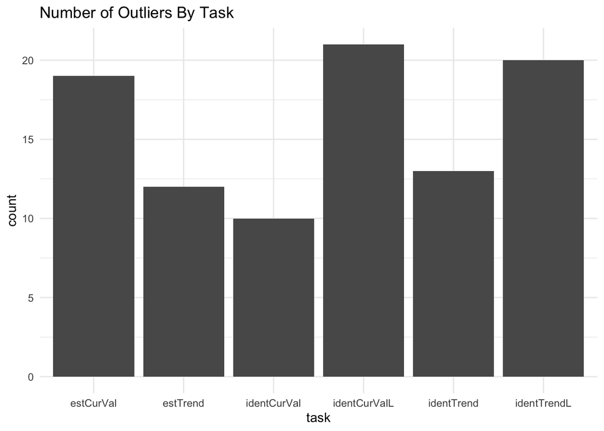

```r
ggplot(data.outliers) +
  geom_bar(aes(x = task)) +
  theme_minimal() +
  ggtitle("Number of Outliers By Task")
```

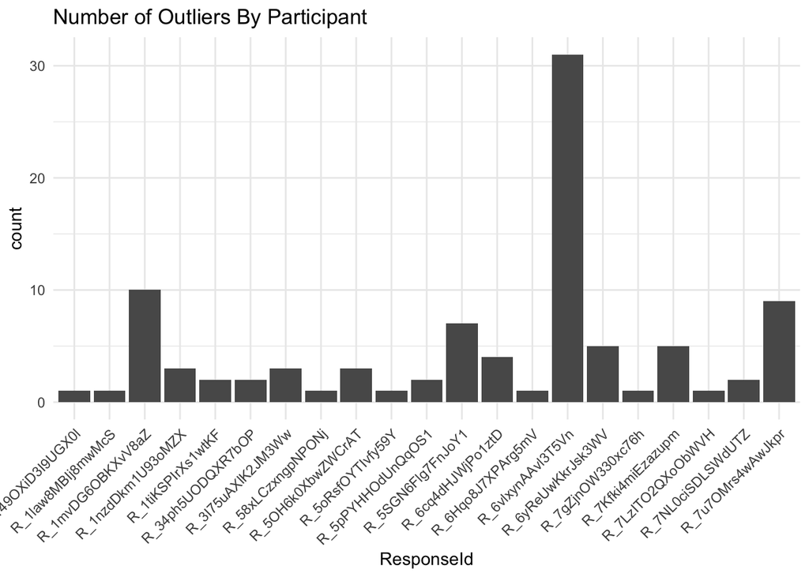

```r
ggplot(data.outliers) +
  geom_bar(aes(x = ResponseId)) +
  theme_minimal() +
  theme(axis.text.x = element_text(angle = 45, hjust=1)) +
  ggtitle("Number of Outliers By Participant")
```

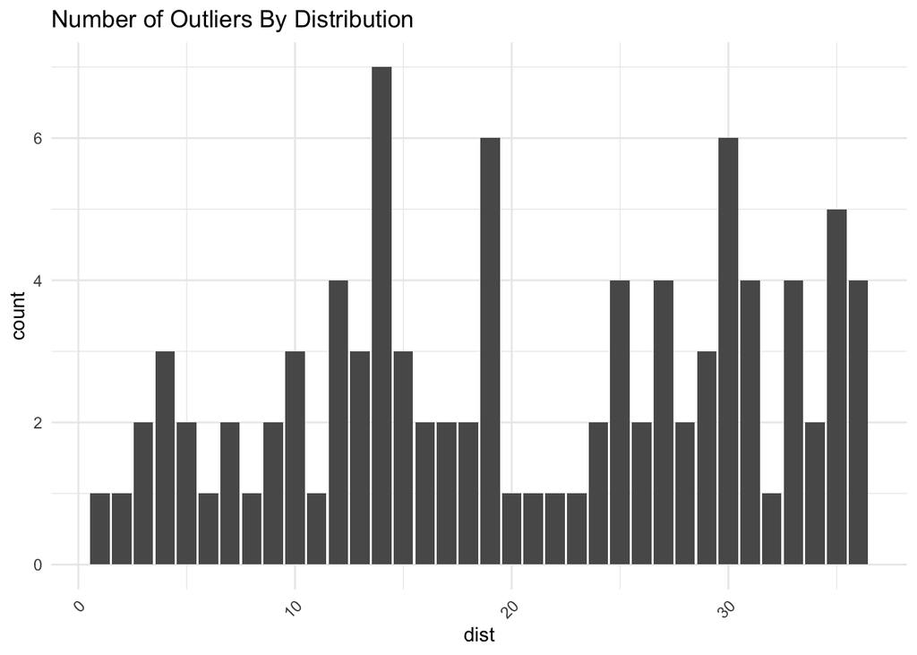

```r
ggplot(data.outliers) +
  geom_bar(aes(x = dist)) +
  theme_minimal() +
  theme(axis.text.x = element_text(angle = 45, hjust=1)) +
  ggtitle("Number of Outliers By Distribution")
```

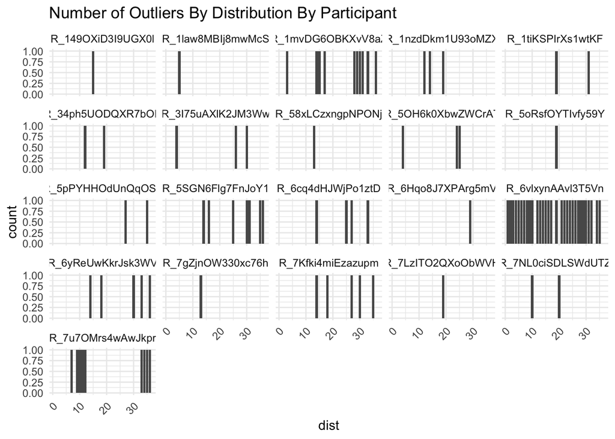

```r
ggplot(data.outliers) +
  geom_bar(aes(x = dist)) +
  facet_wrap(~ResponseId) +
  theme_minimal() +
  theme(axis.text.x = element_text(angle = 45, hjust=1)) +
  ggtitle("Number of Outliers By Distribution By Participant")
```

```r
# data.outliers %>% group_by(ResponseId) %>% count(outlier)
# "R_6vlxynAAvl3T5Vn"
```

## Participant Analysis

```r
data.identCurVal <- data.identCurVal %>%
  mutate(task = "identCurVal")

data.identTrend <- data.identTrend %>%
  mutate(task = "identTrend")

data.estCurVal <- data.estCurVal %>%
  mutate(task = "estCurVal")

data.estTrend <- data.estTrend %>%
  mutate(task = "estTrend")

data.identCurValL <- data.identCurValL %>%
  mutate(task = "identCurValL")

data.identTrendL <- data.identTrendL %>%
  mutate(task = "identTrendL")

data.identCurVal$ResponseId <- factor(data.identCurVal$ResponseId)
data.identTrend$ResponseId <- factor(data.identTrend$ResponseId)
data.estCurVal$ResponseId <- factor(data.estCurVal$ResponseId)
data.estTrend$ResponseId <- factor(data.estTrend$ResponseId)
data.identCurValL$ResponseId <- factor(data.identCurValL$ResponseId)
data.identTrendL$ResponseId <- factor(data.identTrendL$ResponseId)

data.participant <- bind_rows(data.identCurVal, data.identTrend,
                              data.estCurVal, data.estTrend,
                              data.identCurValL, data.identTrendL)

participantMeans <- data.participant %>%
  group_by(ResponseId) %>%
  mutate(mean = mean(time),
         sd = sd(time)) %>%
  arrange(desc(mean)) %>%
  ungroup()

participantMeans <- participantMeans %>%
  distinct(ResponseId, .keep_all = T) %>%
  arrange(desc(mean)) %>%
  mutate(index = row_number()) %>%
  full_join(participantMeans) %>%
  arrange(ResponseId) %>%
  fill(index, .direction = "down")
```

[output not shown]

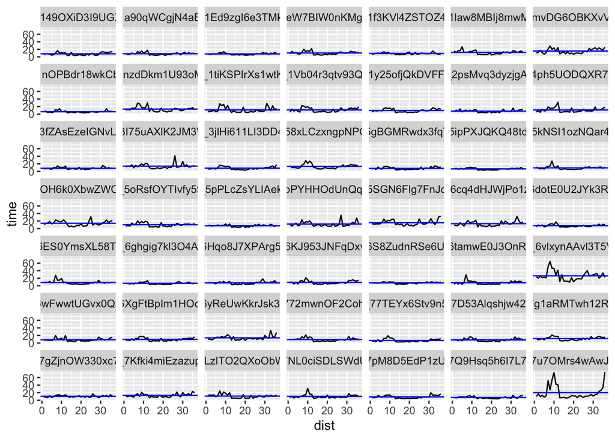

```r
ggplot(data = participantMeans) +
  geom_line(aes(x = dist, y = time, group = ResponseId)) +
  # scale_y_continuous(limits = c(NA, 45)) +
  facet_wrap(~ResponseId) +
  # geom_smooth(aes(x = question, y = time, group = ResponseId),
  #             se = F, method = "lm") +
  geom_hline(aes(yintercept = mean), color = "blue")
```

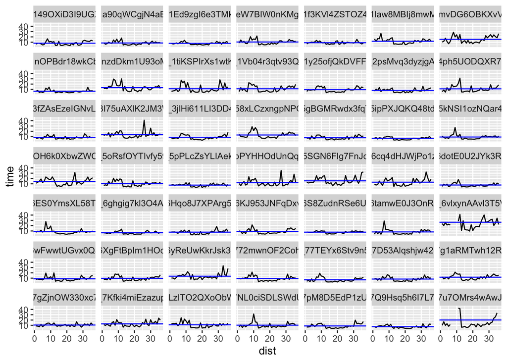

```r
ggplot(data = participantMeans) +
  geom_line(aes(x = dist, y = time, group = ResponseId)) +
  scale_y_continuous(limits = c(NA, 45)) +
  facet_wrap(~ResponseId) +
  # geom_smooth(aes(x = question, y = time, group = ResponseId),
  #             se = F, method = "lm") +
  geom_hline(aes(yintercept = mean), color = "blue")
```

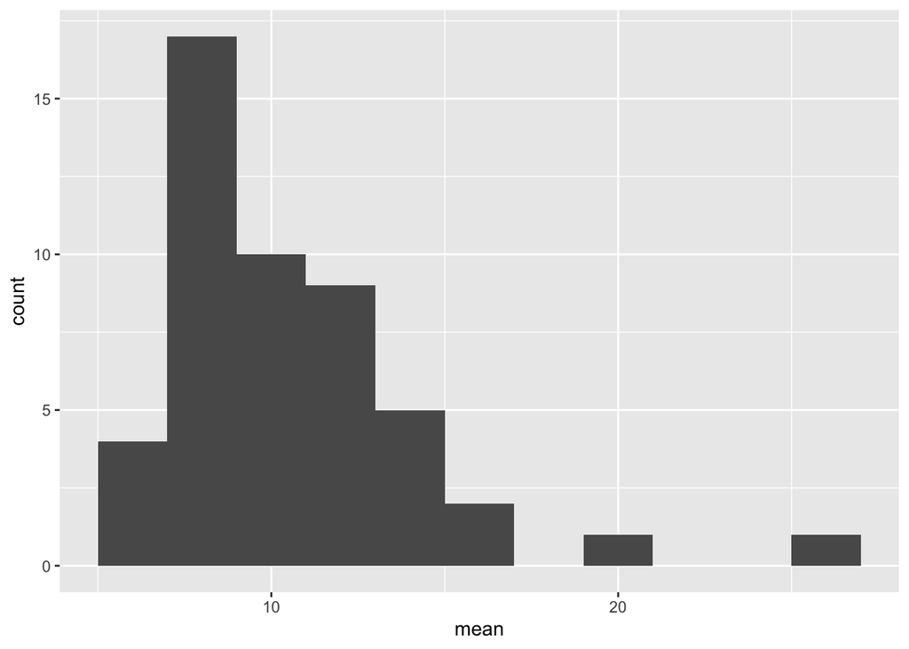

```r
participantMeans.distinct <- participantMeans %>%
  distinct(ResponseId, .keep_all = T)

ggplot(participantMeans.distinct) +
  geom_histogram(aes(mean), binwidth = 2)
```

```r
participantMeans %>% filter(index <= 5) %>% distinct(ResponseId) %>% pull(ResponseId)
```

```
## [1] R_1mvDG6OBKXvV8aZ R_5OH6k0XbwZWCrAT R_5SGN6Flg7FnJoY1 R_6vlxynAAvl3T5Vn
## [5] R_7u7OMrs4wAwJkpr
## 49 Levels: R_149OXiD3I9UGX0l R_1a90qWCgjN4aB8Q ... R_7u7OMrs4wAwJkpr
```

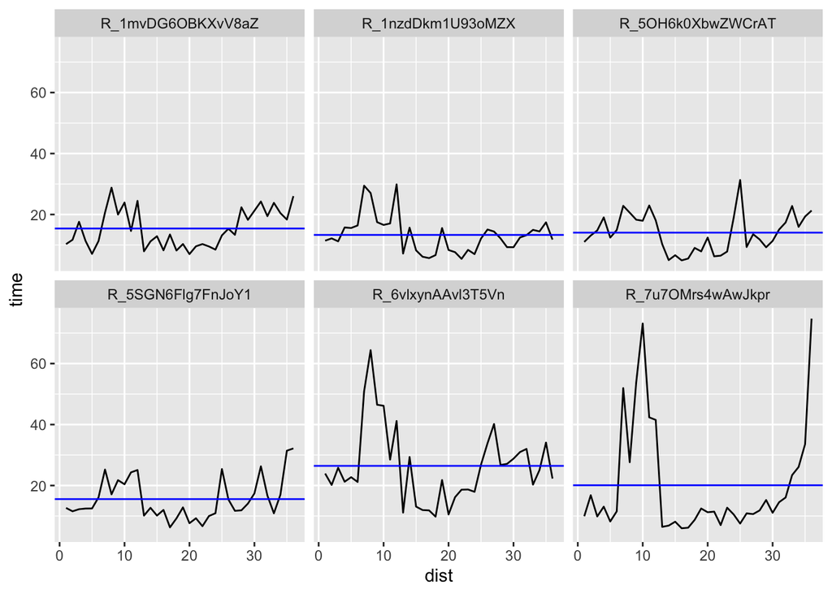

```r
ggplot(data = participantMeans %>% filter(ResponseId %in% c("R_1mvDG6OBKXvV8aZ", "R_1nzdDkm1U93oMZX",
                                                            "R_5SGN6Flg7FnJoY1", "R_6vlxynAAvl3T5Vn",
                                                            "R_7u7OMrs4wAwJkpr", "R_5OH6k0XbwZWCrAT"))) +
  geom_line(aes(x = dist, y = time, group = ResponseId)) +
  facet_wrap(~ResponseId) +
  geom_hline(aes(yintercept = mean), color = "blue")
```

```r
# outliercutoffs <- data.outliers %>% distinct(question, outlier)
#
# participantMeans.cutoffs <- participantMeans %>%
#   left_join(outliercutoffs, by = "task")
#
# ggplot(data = participantMeans.cutoffs) +
#   geom_line(aes(x = question, y = time, group = ResponseId)) +
#   facet_wrap(~ResponseId) +
#   geom_line(aes(x = question, y = outliercutoff, group = ResponseId), color = "blue")
#
# participantMeans.identCurVal <- participantMeans %>%
#   filter(task == "identCurVal") %>%
#   left_join(outliercutoffs, by = "task")
#
# ggplot(data = participantMeans.identCurVal) +
#   geom_line(aes(x = question, y = time, group = ResponseId)) +
#   geom_point(aes(x = question, y = time, group = ResponseId)) +
#   scale_y_continuous(limits = c(NA, 60)) +
#   facet_wrap(~ResponseId) +
#   geom_hline(aes(yintercept = outliercutoff), color = "blue") +
#   ggtitle("Identification Current Value")
#
# participantMeans.identTrend <- participantMeans %>%
#   filter(task == "identTrend") %>%
#   left_join(outliercutoffs, by = "task")
#
# ggplot(data = participantMeans.identTrend) +
#   geom_line(aes(x = question, y = time, group = ResponseId)) +
#   geom_point(aes(x = question, y = time, group = ResponseId)) +
#   scale_y_continuous(limits = c(NA, 60)) +
#   facet_wrap(~ResponseId) +
#   geom_hline(aes(yintercept = outliercutoff), color = "blue") +
#   ggtitle("Identification Trend")
#
# participantMeans.estCurVal <- participantMeans %>%
#   filter(task == "estCurVal") %>%
#   left_join(outliercutoffs, by = "task")
#
# ggplot(data = participantMeans.estCurVal) +
#   geom_line(aes(x = question, y = time, group = ResponseId)) +
#   geom_point(aes(x = question, y = time, group = ResponseId)) +
#   scale_y_continuous(limits = c(NA, 60)) +
#   facet_wrap(~ResponseId) +
#   geom_hline(aes(yintercept = outliercutoff), color = "blue") +
#   ggtitle("Estimation Current Value")
#
# participantMeans.estTrend <- participantMeans %>%
#   filter(task == "estTrend") %>%
#   left_join(outliercutoffs, by = "task")
#
# ggplot(data = participantMeans.estTrend) +
#   geom_line(aes(x = question, y = time, group = ResponseId)) +
#   geom_point(aes(x = question, y = time, group = ResponseId)) +
#   scale_y_continuous(limits = c(NA, 60)) +
#   facet_wrap(~ResponseId) +
#   geom_hline(aes(yintercept = outliercutoff), color = "blue") +
#   ggtitle("Estimation Trend")
```

## ERROR ANALYSIS

```r
#Ident Cur Val
with(data.identCurVal, table(graph, ans_TF))
```

```
##           ans_TF
## graph      FALSE TRUE
##   Control      1   48
##   Emphasis     1   48
##   IntPos       0   49
##   IntSize      1   48
##   SepPos       5   44
##   SepSize      0   49
```

```r
#Ident Trend
with(data.identTrend, table(graph, ans_TF))
```

```
##           ans_TF
## graph      FALSE TRUE
##   Control      1   48
##   Emphasis     4   45
##   IntPos       1   48
##   IntSize      1   48
##   SepPos       0   49
##   SepSize      2   47
```

```r
#Est Cur Val
with(data.estCurVal, table(graph, ans_TF))
```

```
##           ans_TF
## graph      TRUE
##   Control    49
##   Emphasis   49
##   IntPos     49
##   IntSize    49
##   SepPos     49
##   SepSize    49
```

```r
#Est Trend
with(data.estTrend, table(graph, ans_TF))
```

```
##           ans_TF
## graph      FALSE TRUE
##   Control      3   46
##   Emphasis     2   47
##   IntPos       8   41
##   IntSize      4   45
##   SepPos       4   45
##   SepSize      6   43
```

```r
#Ident Cur Val L
with(data.identCurValL, table(graph, ans_TF))
```

```
##           ans_TF
## graph      FALSE TRUE
##   Control      4   45
##   Emphasis     2   47
##   IntPos       2   47
##   IntSize      5   44
##   SepPos       2   47
##   SepSize      3   46
```

```r
#Ident Trend L
with(data.identTrendL, table(graph, ans_TF))
```

```
##           ans_TF
## graph      FALSE TRUE
##   Control      3   46
##   Emphasis     5   44
##   IntPos       2   47
##   IntSize      6   43
##   SepPos       1   48
##   SepSize      1   48
```

```r
#Ident Cur Val
with(data.identCurVal, table(dist, ans_TF))
```

```
##     ans_TF
## dist FALSE TRUE
##    1     0   49
##    2     3   46
##    3     0   49
##    4     3   46
##    5     1   48
##    6     1   48
```

```r
#Ident Trend
with(data.identTrend, table(dist, ans_TF))
```

```
##     ans_TF
## dist FALSE TRUE
##   7      3   46
##   8      0   49
##   9      4   45
##   10     1   48
##   11     0   49
##   12     1   48
```

```r
#Est Cur Val
with(data.estCurVal, table(dist, ans_TF))
```

```
##     ans_TF
## dist TRUE
##   13   49
##   14   49
##   15   49
##   16   49
##   17   49
##   18   49
```

```r
#Est Trend
with(data.estTrend, table(dist, ans_TF))
```

```
##     ans_TF
## dist FALSE TRUE
##   19    15   34
##   20     1   48
##   21     1   48
##   22     1   48
##   23     8   41
##   24     1   48
```

```r
#Ident Cur Val L
with(data.identCurValL, table(dist, ans_TF))
```

```
##     ans_TF
## dist FALSE TRUE
##   25     1   48
##   26     5   44
##   27     1   48
##   28     2   47
##   29     4   45
##   30     5   44
```

```r
#Ident Trend L
with(data.identTrendL, table(dist, ans_TF))
```

```
##     ans_TF
## dist FALSE TRUE
##   31     1   48
##   32     5   44
##   33     3   46
##   34     2   47
##   35     3   46
##   36     4   45
```

```r
data.estTrend %>% filter(dist == 19) %>% count(graph, ans_TF) # %>% view()
```

```
## # A tibble: 11 × 3
##    graph    ans_TF     n
##    <chr>    <lgl>  <int>
##  1 Control  TRUE       8
##  2 Emphasis FALSE      2
##  3 Emphasis TRUE       6
##  4 IntPos   FALSE      3
##  5 IntPos   TRUE       5
##  6 IntSize  FALSE      2
##  7 IntSize  TRUE       6
##  8 SepPos   FALSE      4
##  9 SepPos   TRUE       5
## 10 SepSize  FALSE      4
## 11 SepSize  TRUE       4
```

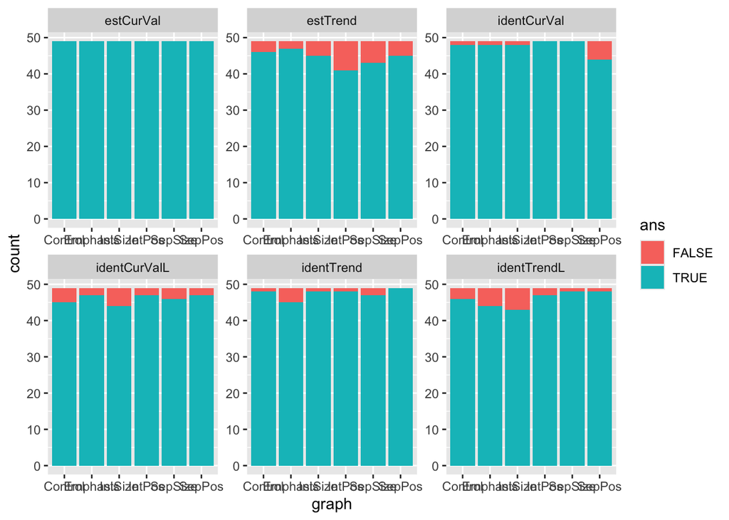

```r
ggplot(data = data.participant %>% mutate(ans = factor(ans_TF),
                                          graph = factor(graph, levels = c("Control", "Emphasis", "IntSize",
                                          "IntPos", "SepSize", "SepPos"), ordered = T))) +
  geom_bar(aes(x = graph, group = ans, fill = ans), position = position_stack()) +
  lemon::facet_rep_wrap(~task, repeat.tick.labels = T)
```

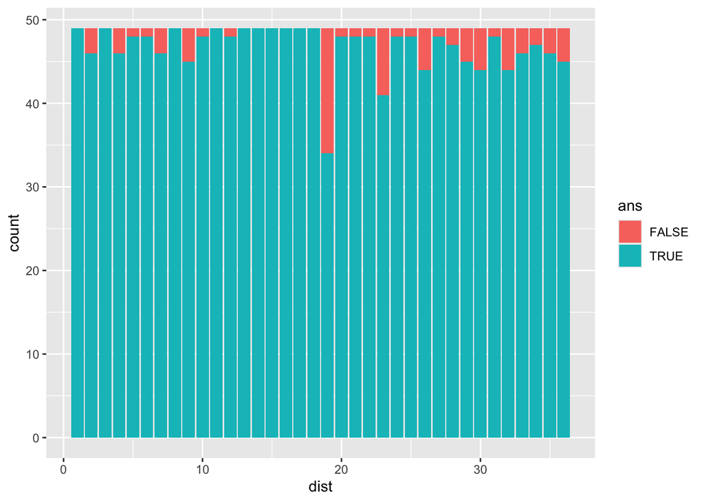

```r
ggplot(data = data.participant %>% mutate(ans = factor(ans_TF))) +
  geom_bar(aes(x = dist, group = ans, fill = ans), position = position_stack())
```

Modified error analysis following reviewer comments:

```r
error_models = data.clean.answerscoded.outliers |>
  group_by(question) |>
  group_modify(\(data, groups) {
    model = glmmTMB(
          ans_TF ~ graph + (1 | ResponseId),
          data = data,
          family = binomial(link = "logit"),
          prior = tribble(
            ~prior,           ~class,  ~coef,
            "cauchy(0, 10)",  "fixef", "(Intercept)", # control
            "cauchy(0, 2.5)", "fixef", ""             # differences from control
            )
          )
    basemodel = glmmTMB(
          ans_TF ~ (1 | ResponseId),
          data = data,
          family = binomial(link = "logit"),
          prior = tribble(
            ~prior,           ~class,  ~coef,
            "cauchy(0, 10)",  "fixef", "(Intercept)", # control
            "cauchy(0, 2.5)", "fixef", ""             # differences from control
            )
          )

    estimates = model |>
      emmeans(~ graph) |>
      contrast(method = "revpairwise")

    # unlike for the time models, we'll just look at the estimated proportion
    # of correct answers for an average participant in each graph type
    intervals = model |>
      emmeans(~ graph) |>
      confint(type = "response") |>
      rename(any_of(c(
        lower = "asymp.LCL", lower = "lower.CL",
        upper = "asymp.UCL", upper = "upper.CL"
      )))

    tibble(
      model = list(model),
      basemodel = list(basemodel),
      estimates = list(estimates),
      intervals = list(intervals)
    )
  }) |>
  ungroup()
```

```r
error_models
```

```
## # A tibble: 6 × 5
##   question     model     basemodel estimates intervals
##   <fct>        <list>    <list>    <list>    <list>
## 1 IdentCurVal  <glmmTMB> <glmmTMB> <emmGrid> <smmry_mm [6 × 6]>
## 2 IdentCurValL <glmmTMB> <glmmTMB> <emmGrid> <smmry_mm [6 × 6]>
## 3 IdentTrend   <glmmTMB> <glmmTMB> <emmGrid> <smmry_mm [6 × 6]>
## 4 IdentTrendL  <glmmTMB> <glmmTMB> <emmGrid> <smmry_mm [6 × 6]>
## 5 EstCurVal    <glmmTMB> <glmmTMB> <emmGrid> <smmry_mm [6 × 6]>
## 6 EstTrend     <glmmTMB> <glmmTMB> <emmGrid> <smmry_mm [6 × 6]>
```

```r
error_models$model[[1]]
```

```
## Formula:          ans_TF ~ graph + (1 | ResponseId)
## Data: data
##       AIC       BIC    logLik -2*log(L)  df.resid
## 106.13034 131.91540 -46.06517  92.13034       287
## Random-effects (co)variances:
##
## Conditional model:
##  Groups     Name        Std.Dev.
##  ResponseId (Intercept) 0.0001005
##
## Number of obs: 294 / Conditional model: ResponseId, 49
##
## Fixed Effects:
##
## Conditional model:
##   (Intercept)  graphEmphasis   graphIntSize    graphIntPos   graphSepSize
##       3.98008       -0.08183       -0.08183        1.11666        1.11666
##   graphSepPos
##      -1.71923
##
## Priors: fixef((Intercept)) ~ cauchy(0, 10); fixef ~ cauchy(0, 2.5)
```

```r
error_models$model[[2]]
```

```
## Formula:          ans_TF ~ graph + (1 | ResponseId)
## Data: data
##       AIC       BIC    logLik -2*log(L)  df.resid
## 155.65726 181.44232 -70.82863 141.65726       287
## Random-effects (co)variances:
##
## Conditional model:
##  Groups     Name        Std.Dev.
##  ResponseId (Intercept) 3.577
##
## Number of obs: 294 / Conditional model: ResponseId, 49
##
## Fixed Effects:
##
## Conditional model:
##   (Intercept)  graphEmphasis   graphIntSize    graphIntPos   graphSepSize
##        5.5216         0.7276        -0.5407         0.7276         0.2276
##   graphSepPos
##        0.7276
##
## Priors: fixef((Intercept)) ~ cauchy(0, 10); fixef ~ cauchy(0, 2.5)
```

```r
error_models$model[[3]]
```

```
## Formula:          ans_TF ~ graph + (1 | ResponseId)
## Data: data
##       AIC       BIC    logLik -2*log(L)  df.resid
## 116.24386 142.02892 -51.12193 102.24386       287
## Random-effects (co)variances:
##
## Conditional model:
##  Groups     Name        Std.Dev.
##  ResponseId (Intercept) 1.339
##
## Number of obs: 294 / Conditional model: ResponseId, 49
##
## Fixed Effects:
##
## Conditional model:
##   (Intercept)  graphEmphasis   graphIntSize    graphIntPos   graphSepSize
##        4.4690        -1.2846         0.1138         0.1138        -0.5041
##   graphSepPos
##        1.3017
##
## Priors: fixef((Intercept)) ~ cauchy(0, 10); fixef ~ cauchy(0, 2.5)
```

```r
error_models$model[[4]]
```

```
## Formula:          ans_TF ~ graph + (1 | ResponseId)
## Data: data
##       AIC       BIC    logLik -2*log(L)  df.resid
## 161.25893 187.04399 -73.62947 147.25893       287
## Random-effects (co)variances:
##
## Conditional model:
##  Groups     Name        Std.Dev.
##  ResponseId (Intercept) 1.842
##
## Number of obs: 294 / Conditional model: ResponseId, 49
##
## Fixed Effects:
##
## Conditional model:
##   (Intercept)  graphEmphasis   graphIntSize    graphIntPos   graphSepSize
##        4.0160        -0.6827        -0.9384         0.3789         0.9769
##   graphSepPos
##        0.9769
##
## Priors: fixef((Intercept)) ~ cauchy(0, 10); fixef ~ cauchy(0, 2.5)
```

```r
error_models$model[[5]]
```

```
## Formula:          ans_TF ~ graph + (1 | ResponseId)
## Data: data
##       AIC       BIC    logLik -2*log(L)  df.resid
##  42.68734  68.47240 -14.34367  28.68734       287
## Random-effects (co)variances:
##
## Conditional model:
##  Groups     Name        Std.Dev.
##  ResponseId (Intercept) 0.0001778
##
## Number of obs: 294 / Conditional model: ResponseId, 49
##
## Fixed Effects:
##
## Conditional model:
##   (Intercept)  graphEmphasis   graphIntSize    graphIntPos   graphSepSize
##       7.96961        0.05036        0.05036        0.05036        0.05036
##   graphSepPos
##       0.05036
##
## Priors: fixef((Intercept)) ~ cauchy(0, 10); fixef ~ cauchy(0, 2.5)
```

```r
error_models$model[[6]]
```

```
## Formula:          ans_TF ~ graph + (1 | ResponseId)
## Data: data
##       AIC       BIC    logLik -2*log(L)  df.resid
##  216.9208  242.7058 -101.4604  202.9208       287
## Random-effects (co)variances:
##
## Conditional model:
##  Groups     Name        Std.Dev.
##  ResponseId (Intercept) 0.0007493
##
## Number of obs: 294 / Conditional model: ResponseId, 49
##
## Fixed Effects:
##
## Conditional model:
##   (Intercept)  graphEmphasis   graphIntSize    graphIntPos   graphSepSize
##        2.5869         0.4936        -0.1532        -0.9138        -0.5834
##   graphSepPos
##       -0.1532
##
## Priors: fixef((Intercept)) ~ cauchy(0, 10); fixef ~ cauchy(0, 2.5)
```

```r
print(error_models$question[[1]])
```

```
## [1] IdentCurVal
## 6 Levels: IdentCurVal IdentCurValL IdentTrend IdentTrendL ... EstTrend
```

```r
anova(error_models$basemodel[[1]], error_models$model[[1]])
```

```
## Data: data
## Models:
## error_models$basemodel[[1]]: ans_TF ~ (1 | ResponseId), zi=~0, disp=~1
## error_models$model[[1]]: ans_TF ~ graph + (1 | ResponseId), zi=~0, disp=~1
##                             Df     AIC     BIC  logLik deviance Chisq Chi Df
## error_models$basemodel[[1]]  2  84.581  91.949 -40.291   80.581
## error_models$model[[1]]      7 106.130 131.915 -46.065   92.130     0      5
##                             Pr(>Chisq)
## error_models$basemodel[[1]]
## error_models$model[[1]]              1
```

```r
print(error_models$question[[2]])
```

```
## [1] IdentCurValL
## 6 Levels: IdentCurVal IdentCurValL IdentTrend IdentTrendL ... EstTrend
```

```r
anova(error_models$basemodel[[2]], error_models$model[[2]])
```

```
## Data: data
## Models:
## error_models$basemodel[[2]]: ans_TF ~ (1 | ResponseId), zi=~0, disp=~1
## error_models$model[[2]]: ans_TF ~ graph + (1 | ResponseId), zi=~0, disp=~1
##                             Df    AIC    BIC  logLik deviance Chisq Chi Df
## error_models$basemodel[[2]]  2 128.30 135.67 -62.151   124.30
## error_models$model[[2]]      7 155.66 181.44 -70.829   141.66     0      5
##                             Pr(>Chisq)
## error_models$basemodel[[2]]
## error_models$model[[2]]              1
```

```r
print(error_models$question[[3]])
```

```
## [1] IdentTrend
## 6 Levels: IdentCurVal IdentCurValL IdentTrend IdentTrendL ... EstTrend
```

```r
anova(error_models$basemodel[[3]], error_models$model[[3]])
```

```
## Data: data
## Models:
## error_models$basemodel[[3]]: ans_TF ~ (1 | ResponseId), zi=~0, disp=~1
## error_models$model[[3]]: ans_TF ~ graph + (1 | ResponseId), zi=~0, disp=~1
##                             Df     AIC     BIC  logLik deviance Chisq Chi Df
## error_models$basemodel[[3]]  2  90.848  98.215 -43.424   86.848
## error_models$model[[3]]      7 116.244 142.029 -51.122  102.244     0      5
##                             Pr(>Chisq)
## error_models$basemodel[[3]]
## error_models$model[[3]]              1
```

```r
print(error_models$question[[4]])
```

```
## [1] IdentTrendL
## 6 Levels: IdentCurVal IdentCurValL IdentTrend IdentTrendL ... EstTrend
```

```r
anova(error_models$basemodel[[4]], error_models$model[[4]])
```

```
## Data: data
## Models:
## error_models$basemodel[[4]]: ans_TF ~ (1 | ResponseId), zi=~0, disp=~1
## error_models$model[[4]]: ans_TF ~ graph + (1 | ResponseId), zi=~0, disp=~1
##                             Df    AIC    BIC  logLik deviance Chisq Chi Df
## error_models$basemodel[[4]]  2 138.73 146.10 -67.365   134.73
## error_models$model[[4]]      7 161.26 187.04 -73.629   147.26     0      5
##                             Pr(>Chisq)
## error_models$basemodel[[4]]
## error_models$model[[4]]              1
```

```r
print(error_models$question[[5]])
```

```
## [1] EstCurVal
## 6 Levels: IdentCurVal IdentCurValL IdentTrend IdentTrendL ... EstTrend
```

```r
anova(error_models$basemodel[[5]], error_models$model[[5]])
```

```
## Data: data
## Models:
## error_models$basemodel[[5]]: ans_TF ~ (1 | ResponseId), zi=~0, disp=~1
## error_models$model[[5]]: ans_TF ~ graph + (1 | ResponseId), zi=~0, disp=~1
##                             Df    AIC    BIC   logLik deviance Chisq Chi Df
## error_models$basemodel[[5]]  2 12.081 19.448  -4.0406   8.0812
## error_models$model[[5]]      7 42.687 68.472 -14.3437  28.6873     0      5
##                             Pr(>Chisq)
## error_models$basemodel[[5]]
## error_models$model[[5]]              1
```

```r
print(error_models$question[[6]])
```

```
## [1] EstTrend
## 6 Levels: IdentCurVal IdentCurValL IdentTrend IdentTrendL ... EstTrend
```

```r
anova(error_models$basemodel[[6]], error_models$model[[6]])
```

```
## Data: data
## Models:
## error_models$basemodel[[6]]: ans_TF ~ (1 | ResponseId), zi=~0, disp=~1
## error_models$model[[6]]: ans_TF ~ graph + (1 | ResponseId), zi=~0, disp=~1
##                             Df    AIC    BIC   logLik deviance Chisq Chi Df
## error_models$basemodel[[6]]  2 191.38 198.74  -93.688   187.38
## error_models$model[[6]]      7 216.92 242.71 -101.460   202.92     0      5
##                             Pr(>Chisq)
## error_models$basemodel[[6]]
## error_models$model[[6]]              1
```

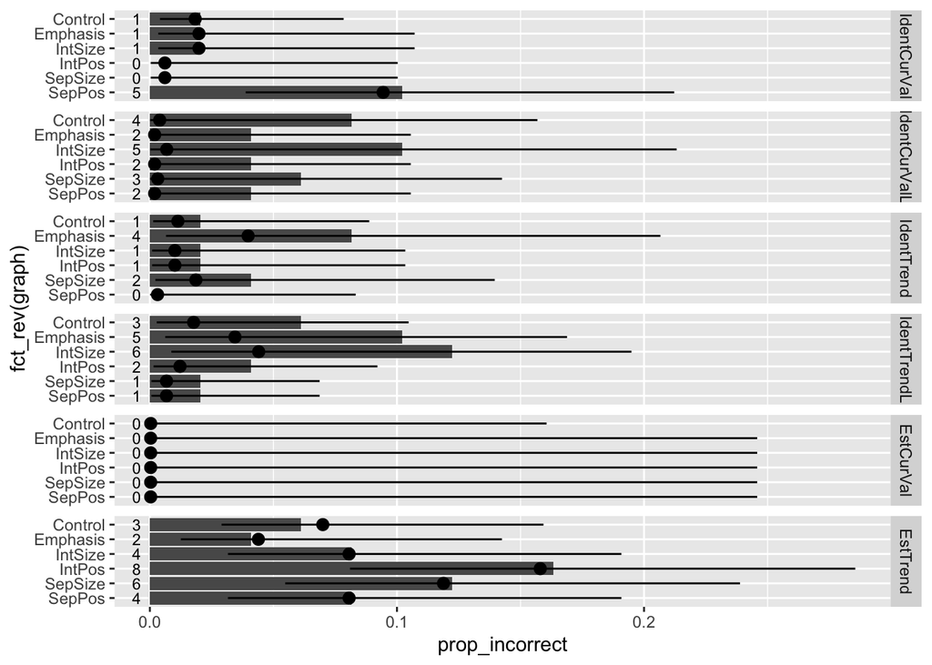

```r
data.clean.answerscoded.outliers |>
  summarise(
    incorrect = n() - sum(ans_TF),
    prop_incorrect = incorrect/n(),
    .by = c(question, graph)
  ) |>
  ggplot(aes(y = fct_rev(graph))) +
  geom_col(aes(x = prop_incorrect)) +
  geom_pointrange(
    aes(x = 1 - prob, xmin = 1 - upper, xmax = 1 - lower),
    position = position_dodge(width = 0.8),
    fill = NA,
    data = error_models |> select(question, intervals) |> unnest(intervals)
  ) +
  geom_text(aes(x = 0, label = incorrect), size = 3, hjust = 2) +
  facet_grid(rows = vars(question))
```

## LIKERT & QUALITATIVE ANALYSIS

```r
data.clean.answerscoded %>%
  count(`Standard Ratings`)
```

```
## # A tibble: 4 × 2
##   `Standard Ratings`             n
##   <chr>                      <int>
## 1 Neither easy nor difficult   259
## 2 Somewhat difficult           370
## 3 Somewhat easy                740
## 4 Very easy                    444
```

```r
data.clean.answerscoded %>%
  count(`Emphasis Ratings`)
```

```
## # A tibble: 4 × 2
##   `Emphasis Ratings`             n
##   <chr>                      <int>
## 1 Neither easy nor difficult   222
## 2 Somewhat difficult            74
## 3 Somewhat easy                851
## 4 Very easy                    666
```

```r
data.clean.answerscoded %>%
  count(`IntSize Ratings`)
```

```
## # A tibble: 5 × 2
##   `IntSize Ratings`              n
##   <chr>                      <int>
## 1 Neither easy nor difficult   148
## 2 Somewhat difficult            74
## 3 Somewhat easy                333
## 4 Very difficult                37
## 5 Very easy                   1221
```

```r
data.clean.answerscoded %>%
  count(`IntPos Ratings`)
```

```
## # A tibble: 4 × 2
##   `IntPos Ratings`               n
##   <chr>                      <int>
## 1 Neither easy nor difficult   185
## 2 Somewhat difficult           148
## 3 Somewhat easy                740
## 4 Very easy                    740
```

```r
data.clean.answerscoded %>%
  count(`SepSize Ratings`)
```

```
## # A tibble: 4 × 2
##   `SepSize Ratings`              n
##   <chr>                      <int>
## 1 Neither easy nor difficult   148
## 2 Somewhat difficult            37
## 3 Somewhat easy                481
## 4 Very easy                   1147
```

```r
data.clean.answerscoded %>%
  count(`SepPos Ratings`)
```

```
## # A tibble: 5 × 2
##   `SepPos Ratings`               n
##   <chr>                      <int>
## 1 Neither easy nor difficult   444
## 2 Somewhat difficult           296
## 3 Somewhat easy                703
## 4 Very difficult                37
## 5 Very easy                    333
```

```r
data.clean.likert <- data.clean.answerscoded %>%
  distinct(ResponseId, .keep_all = T) %>%
  select(ResponseId, `Standard Ratings`, `Emphasis Ratings`, `IntSize Ratings`, `IntPos Ratings`,
         `SepSize Ratings`, `SepPos Ratings`) %>%
  mutate(standard = factor(`Standard Ratings`, levels = c("Very difficult", "Somewhat difficult",
                        "Neither easy nor difficult", "Somewhat easy", "Very easy"), ordered = T),
         standard = as.numeric(standard),
         emphasis = factor(`Emphasis Ratings`, levels = c("Very difficult", "Somewhat difficult",
                        "Neither easy nor difficult", "Somewhat easy", "Very easy"), ordered = T),
         emphasis = as.numeric(emphasis),
         intSize = factor(`IntSize Ratings`, levels = c("Very difficult", "Somewhat difficult",
                        "Neither easy nor difficult", "Somewhat easy", "Very easy"), ordered = T),
         intSize = as.numeric(intSize),
         intPos = factor(`IntPos Ratings`, levels = c("Very difficult", "Somewhat difficult",
                        "Neither easy nor difficult", "Somewhat easy", "Very easy"), ordered = T),
         intPos = as.numeric(intPos),
         sepSize = factor(`SepSize Ratings`, levels = c("Very difficult", "Somewhat difficult",
                        "Neither easy nor difficult", "Somewhat easy", "Very easy"), ordered = T),
         sepSize = as.numeric(sepSize),
         sepPos = factor(`SepPos Ratings`, levels = c("Very difficult", "Somewhat difficult",
                        "Neither easy nor difficult", "Somewhat easy", "Very easy"), ordered = T),
         sepPos = as.numeric(sepPos)) %>%
  select(-c(`Standard Ratings`, `Emphasis Ratings`, `IntSize Ratings`, `IntPos Ratings`,
         `SepSize Ratings`, `SepPos Ratings`)) %>%
  pivot_longer(cols = c(standard, emphasis, intSize, intPos, sepSize, sepPos),
               names_to = "graph", values_to = "likert") %>%
  mutate(graph = factor(graph, levels = c("standard", "emphasis", "intSize",
                                          "intPos", "sepSize", "sepPos"), ordered = T))
```

```r
# lm.likert <- lm(likert ~ graph, data = data.clean.likert)
# anova(lm.likert)

anova.likert <- rstatix::anova_test(data = data.clean.likert, likert ~ graph, dv = likert,
                                    wid = ResponseId, within = graph)
rstatix::get_anova_table(anova.likert)
```

```
## ANOVA Table (type II tests)
##
##   Effect DFn DFd     F        p p<.05   ges
## 1  graph   5 288 8.673 1.13e-07     * 0.131
```

```r
model.likert <- lme4::lmer(likert ~ graph + (1|ResponseId), data = data.clean.likert)
model.likert.null <- lme4::lmer(likert ~ (1|ResponseId), data = data.clean.likert)

anova(model.likert.null, model.likert)
```

```
## refitting model(s) with ML (instead of REML)
```

```
## Data: data.clean.likert
## Models:
## model.likert.null: likert ~ (1 | ResponseId)
## model.likert: likert ~ graph + (1 | ResponseId)
##                   npar    AIC    BIC  logLik -2*log(L)  Chisq Df Pr(>Chisq)
## model.likert.null    3 796.02 807.07 -395.01    790.02
## model.likert         8 746.75 776.22 -365.38    730.75 59.271  5  1.719e-11 ***
## ---
## Signif. codes:  0 '***' 0.001 '**' 0.01 '*' 0.05 '.' 0.1 ' ' 1
```

```r
summary(model.likert)
```

```
## Linear mixed model fit by REML ['lmerMod']
## Formula: likert ~ graph + (1 | ResponseId)
##    Data: data.clean.likert
##
## REML criterion at convergence: 746.9
##
## Scaled residuals:
##     Min      1Q  Median      3Q     Max
## -3.3230 -0.4790  0.1799  0.6496  1.8914
##
## Random effects:
##  Groups     Name        Variance Std.Dev.
##  ResponseId (Intercept) 0.2921   0.5405
##  Residual               0.5676   0.7534
## Number of obs: 294, groups:  ResponseId, 49
##
## Fixed effects:
##              Estimate Std. Error t value
## (Intercept)  4.085034   0.088838  45.983
## graph.L      0.002439   0.107625   0.023
## graph.Q     -0.743722   0.107625  -6.910
## graph.C     -0.142987   0.107625  -1.329
## graph^4     -0.300829   0.107625  -2.795
## graph^5     -0.311114   0.107625  -2.891
##
## Correlation of Fixed Effects:
##         (Intr) grph.L grph.Q grph.C grph^4
## graph.L 0.000
## graph.Q 0.000  0.000
## graph.C 0.000  0.000  0.000
## graph^4 0.000  0.000  0.000  0.000
## graph^5 0.000  0.000  0.000  0.000  0.000
```

```r
summary(multcomp::glht(model.likert, linfct=multcomp::mcp(graph="Tukey")))
```

```
##
##   Simultaneous Tests for General Linear Hypotheses
##
## Multiple Comparisons of Means: Tukey Contrasts
##
##
## Fit: lme4::lmer(formula = likert ~ graph + (1 | ResponseId), data = data.clean.likert)
##
## Linear Hypotheses:
##                          Estimate Std. Error z value Pr(>|z|)
## emphasis - standard == 0  0.46939    0.15220   3.084  0.02492 *
## intSize - standard == 0   0.75510    0.15220   4.961  < 0.001 ***
## intPos - standard == 0    0.44898    0.15220   2.950  0.03730 *
## sepSize - standard == 0   0.81633    0.15220   5.363  < 0.001 ***
## sepPos - standard == 0   -0.14286    0.15220  -0.939  0.93654
## intSize - emphasis == 0   0.28571    0.15220   1.877  0.41617
## intPos - emphasis == 0   -0.02041    0.15220  -0.134  0.99999
## sepSize - emphasis == 0   0.34694    0.15220   2.279  0.20239
## sepPos - emphasis == 0   -0.61224    0.15220  -4.023  < 0.001 ***
## intPos - intSize == 0    -0.30612    0.15220  -2.011  0.33567
## sepSize - intSize == 0    0.06122    0.15220   0.402  0.99865
## sepPos - intSize == 0    -0.89796    0.15220  -5.900  < 0.001 ***
## sepSize - intPos == 0     0.36735    0.15220   2.414  0.15143
## sepPos - intPos == 0     -0.59184    0.15220  -3.888  0.00141 **
## sepPos - sepSize == 0    -0.95918    0.15220  -6.302  < 0.001 ***
## ---
## Signif. codes:  0 '***' 0.001 '**' 0.01 '*' 0.05 '.' 0.1 ' ' 1
## (Adjusted p values reported -- single-step method)
```

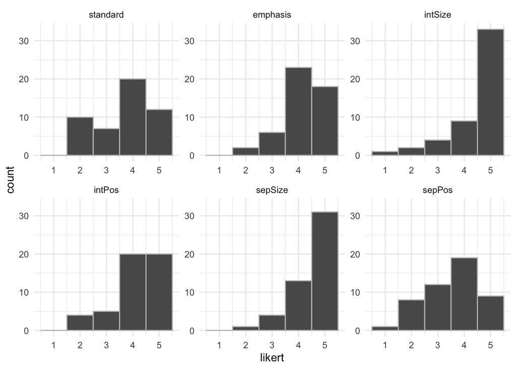

```r
ggplot(data = data.clean.likert, aes(x = likert)) +
  geom_histogram(binwidth = 1, color = "gray75") +
  lemon::facet_rep_wrap(vars(graph), repeat.tick.labels = T) +
  theme_minimal()
```

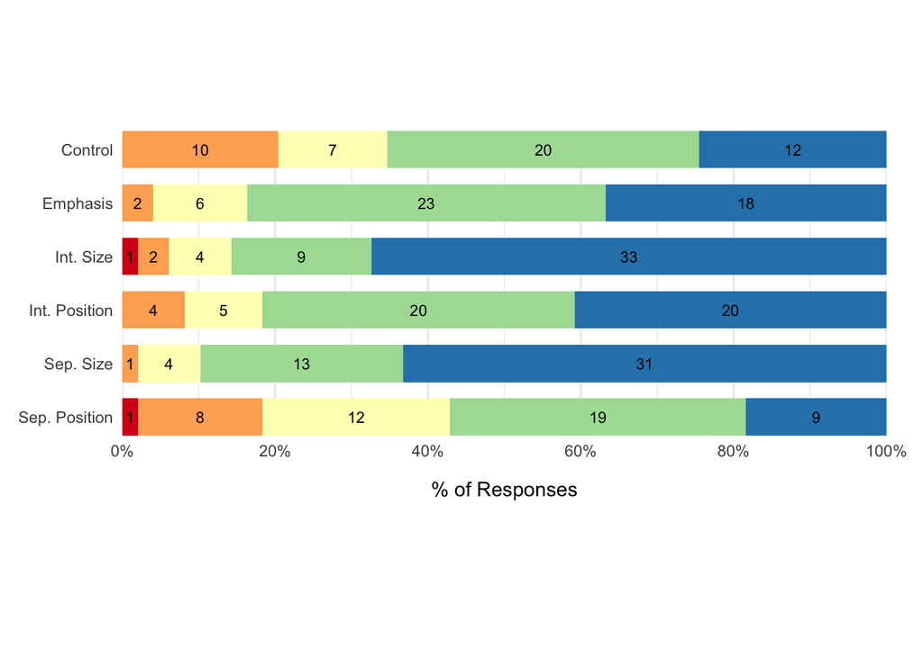

```r
data.clean.likert <- data.clean.likert %>%
  mutate(label = graph,
         label = fct_recode(label,  "Control" = "standard", "Emphasis" = "emphasis", "Int. Size" = "intSize",
                                          "Int. Position" = "intPos", "Sep. Size" = "sepSize",
                            "Sep. Position" = "sepPos"))

data.clean.likert.factor <- data.clean.likert %>%
  mutate(likert = factor(likert, ordered = T, labels = c("1", "2", "3", "4", "5")))

data.clean.likert.summarized <- data.clean.likert.factor %>%
  group_by(label) %>%
  dplyr::count(likert) %>%
  mutate(percent = n/54)

library(RColorBrewer)
ggplot(data = data.clean.likert.factor,
       aes(x = label, fill = reorder(likert, desc(likert)),
               group = reorder(likert, desc(likert)))) +
  geom_bar(width = 0.7, position = "fill") +
  geom_text(aes(label = ..count..), stat = "count",
            position = position_fill(vjust = 0.5),
            size = 3) +
  scale_y_continuous(expand = expansion(mult = c(0, 0)),
                   breaks = c(seq(0, 1, by = .2)),
                   limits = c(0,1),
                   labels = scales::label_percent(),
                   name = "% of Responses") +
  scale_x_discrete(expand = expansion(mult = c(0, 0)), limits = rev) +
  scale_fill_manual(values = rev(brewer.pal(5, "Spectral")), guide = "none") +
  coord_flip() +
  theme_minimal() +
  theme(axis.title.y = element_blank(),
        axis.title.x = element_text(margin = margin(t = 12, r = 0, b = 0, l = 0)),
        axis.text.y = element_text(margin = margin(t = 0, r = 5, b = 0, l = 0)),
        axis.text.x = element_text(margin = margin(t = 5, r = 0, b = 0, l = 0)),
        aspect.ratio = 1/2.5,
        plot.margin = margin(t = 0,
                             r = 20,
                             b = 15,
                             l = 10))
```

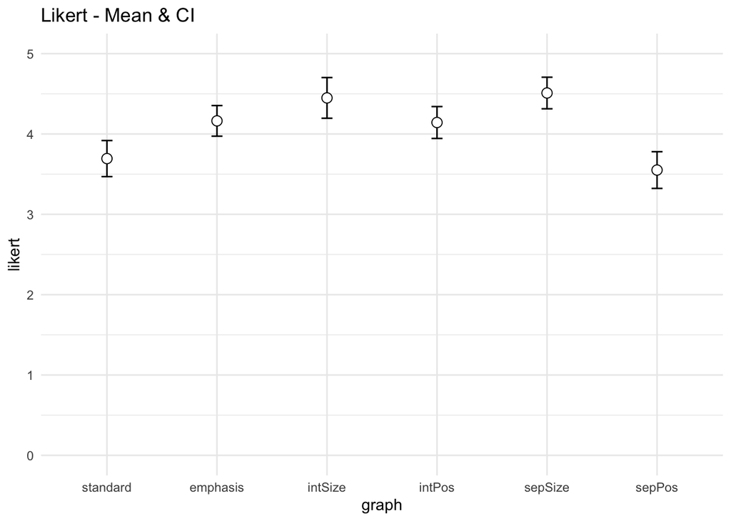

```r
source("ConfidenceIntervalHelperFunctions.R")

data.likert.means <- summarySEwithin(data = data.clean.likert, measurevar = "likert",
                                       withinvars = "graph", idvar = "ResponseId")

ggplot(data.likert.means, aes(x=graph, y=likert, group=1)) +
  geom_errorbar(width=.1, aes(ymin=likert-ci, ymax=likert+ci)) +
  geom_point(shape=21, size=3, fill="white") +
  ylim(0,5) +
  theme_minimal() +
  ggtitle("Likert - Mean & CI")
```

## QUALITATIVE OUTPUT

```r
data.clean.qualitative <- data.clean.answerscoded %>%
  select(ResponseId, QualitativeResponseWhy, Feedback) %>%
  distinct(.keep_all = T)

# write_csv(data.clean.qualitative, "NonComparativeQualitativeResponses_V2.csv")
```

## VISUALIZATIONS

[figure not shown]

```r
percent_change_lim_graph <- percent_change_lim %>%
  add_row(question = "IdentCurVal", contrast = "Control (C)", estimate = 0) %>%
  add_row(question = "IdentTrend", contrast = "Control (C)", estimate = 0) %>%
  add_row(question = "EstCurVal", contrast = "Control (C)", estimate = 0) %>%
  add_row(question = "EstTrend", contrast = "Control (C)", estimate = 0) %>%
  add_row(question = "IdentCurValL", contrast = "Control (C)", estimate = 0) %>%
  add_row(question = "IdentTrendL", contrast = "Control (C)", estimate = 0) %>%
  mutate(
    question = question |> fct_relevel(
      "IdentCurVal",
      "IdentCurValL",
      "IdentTrend",
      "IdentTrendL",
      "EstCurVal",
      "EstTrend"),
    contrast = contrast |>
      fct_relevel(
      "Control (C)",
      "Emphasis - C",
      "Int. Size - C",
      "Int. Position - C",
      "Sep. Size - C",
      "Sep. Position - C")
    )

ggplot(data = percent_change_lim_graph,
       aes(x = estimate, y = contrast)) +
  geom_vline(xintercept = 0, linewidth = 0.3, color = "gray50") +
  geom_errorbar(width=0, aes(xmin=lower,
                             xmax=upper,
                             color = question),
                show.legend = F,
                linewidth = 1.6) +
  geom_point(aes(color = question), shape=21, size=3.6,
             fill="white", show.legend = F) +
  scale_color_manual(values = c("#317F9B","#AA4B53","#13B6B9",
                                "#E2923C","#5F51B8","#9990E0")) +
  scale_x_continuous(limits = c(-0.4,0.4), expand = expansion(mult = c(0, 0)),
                     name = "Percent Change from Control Estimate",
                     labels = scales::percent) +
  scale_y_discrete(limits=rev) +
  facet_grid(rows = vars(question)) +
  theme_minimal() +
  theme(axis.title.y = element_blank(),
        axis.title.x = element_text(margin = margin(t = 12, r = 0, b = 0, l = 0)),
        axis.text.y = element_text(margin = margin(t = 0, r = 5, b = 0, l = 0),
                                   size = rel(1.7)),
        axis.text.x = element_text(margin = margin(t = 5, r = 0, b = 0, l = 0),
                                   size = rel(1.7)),
        plot.margin = margin(t = 10,
                             r = 10,
                             b = 10,
                             l = 10),
        panel.spacing = unit(30, "pt"),
        strip.text.y = element_blank())
```

```r
ggsave("GraphNonComparativeCIs_revision3.svg", width=7, height=11)
ggsave("GraphNonComparativeCIs_revision3.png", width=7, height=11, bg = "white")
```

```r
nrow(data.participant %>% distinct(ResponseId))
```

```
## [1] 49
```

```r
data.participant.error <- data.participant %>%
  mutate(ans = factor(ans_TF)) %>%
  mutate(task = fct_recode(task,
                           "Ident. Current Value Highest" = "identCurVal",
                           "Ident. Current Value Lowest" = "identCurValL",
                           "Ident. Trend Increasing" = "identTrend",
                           "Ident. Trend Decreasing" = "identTrendL",
                           "Lookup Current Value" = "estCurVal",
                           "Lookup Trend" = "estTrend"),
         task = factor(task, levels = c("Ident. Current Value Highest",
                                        "Ident. Current Value Lowest",
                                        "Ident. Trend Increasing",
                        "Ident. Trend Decreasing",
                       "Lookup Current Value","Lookup Trend"), ordered = T),
         label = graph,
         label = fct_recode(label,"Control" = "Control", "Emphasis" = "Emphasis",
                            "Int. Size" = "IntSize", "Int. Position" = "IntPos",
                            "Sep. Size" = "SepSize", "Sep. Position" = "SepPos"),
         label = factor(label, levels = rev(c("Control", "Emphasis",
                            "Int. Size", "Int. Position",
                            "Sep. Size", "Sep. Position")),
                        ordered =T))

# ggplot(data = data.participant.error) +
#   geom_bar(aes(x = label, group = ans, fill = ans), position = position_stack()) +
#   geom_text(data = data.participant.error %>% filter(ans == T),
#             aes(x = label, group = ans, label = ..count..), stat = "count",
#             position = position_fill(vjust = 0.5),
#             size = 3, hjust = 0) +
#   scale_fill_manual(labels = c("Incorrect", "Correct"),
#                     values = c("#EB919A", "#73BCE6"),
#                     name = "Answer Type") +
#   scale_y_continuous(expand = expansion(mult = c(0.01, 0)),
#                      breaks = c(0,10,20,30,40,49),
#                      labels = c("0","10","20","30","40","49"),
#                      name = "Number of Errors") +
#   scale_x_discrete(expand = expansion(mult = c(0.12, 0))) +
#   coord_flip() +
#   facet_grid(rows = vars(task)) +
#   theme_minimal() +
#   theme(axis.title.y = element_blank(),
#         axis.title.x = element_text(margin = margin(t = 12, r = 0, b = 0, l = 0)),
#         axis.text.y = element_text(margin = margin(t = 0, r = 2, b = 0, l = 0)),
#         axis.text.x = element_text(margin = margin(t = 1, r = 0, b = 0, l = 0)),
#         plot.margin = margin(t = 10,
#                              r = 10,
#                              b = 10,
#                              l = 10),
#         panel.spacing = unit(12, "pt"),
#         legend.position = "bottom")

#ggsave("GraphNonComparativeErrors_revision2.pdf", width=5, height=10)
#ggsave("GraphNonComparativeErrors_revision2.png", width=5, height=10, bg = "white")
```

[figure not shown]

```r
data.participant.error.summarize <- data.participant.error %>%
  group_by(task, label, ans) %>%
  count() %>%
  ungroup() %>%
  complete(task, label, ans, fill = list(n = 0))

ggplot(data = data.participant.error.summarize %>% filter(ans == F)) +
  geom_col(aes(x = label, y = n), fill = "#EB919A") +
  geom_text(aes(x = label, y = n, label =  n),
            size = 5, hjust = -0.7) +
  # scale_fill_manual(labels = c("Incorrect", "Correct"),
  #                   values = c("#EB919A", "#73BCE6"),
  #                   name = "Answer Type") +
  scale_y_continuous(expand = expansion(mult = c(0.01, 0)),
                     breaks = c(0,20,40),
                     labels = c("0","20","40"),
                     name = "Number of Errors",
                     limits = c(0,49)) +
  scale_x_discrete(expand = expansion(mult = c(0.12, 0))) +
  coord_flip() +
  facet_grid(rows = vars(task)) +
  theme_minimal() +
  theme(axis.title.y = element_blank(),
        axis.title.x = element_text(margin = margin(t = 12, r = 0, b = 0, l = 0)),
        axis.text.y = element_text(margin = margin(t = 0, r = 2, b = 0, l = 0),
                                   size = rel(1.7)),
        axis.text.x = element_text(margin = margin(t = 1, r = 0, b = 0, l = 0),
                                   size = rel(1.7)),
        plot.margin = margin(t = 10,
                             r = 10,
                             b = 10,
                             l = 10),
        legend.position = "bottom",
        panel.spacing = unit(30, "pt"),
        strip.text.y = element_blank(),
        panel.grid.minor = element_blank(),
        panel.grid.major.x = element_blank(),
        )
```

```r
ggsave("GraphNonComparativeErrors_revision3.svg", width=2.5, height=11)
ggsave("GraphNonComparativeErrors_revision3.png", width=5, height=10, bg = "white")
```

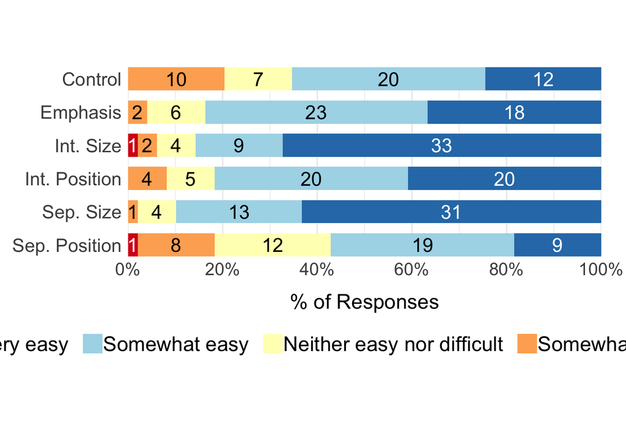

```r
data.clean.likert.summarized <- data.clean.likert.factor %>%
  group_by(label) %>%
  count(likert) %>%
  mutate(percent = n/47)

ggplot(data = data.clean.likert.summarized,
       aes(x = label, y = percent, fill = reorder(likert, desc(likert)),
               group = reorder(likert, desc(likert)))) +
  geom_col(width = 0.7, position = "fill") +
  geom_text(aes(label = n),
            color = ifelse((data.clean.likert.summarized$likert == "1" | data.clean.likert.summarized$likert == "5"),
                           "white", "black"),
            position = position_fill(vjust = 0.5),
            size = 5.5) +
  scale_y_continuous(expand = expansion(mult = c(0, 0)),
                   breaks = c(seq(0, 1, by = .2)),
                   limits = c(0,1),
                   labels = scales::label_percent(),
                   name = "% of Responses") +
  scale_x_discrete(expand = expansion(mult = c(0, 0)), limits = rev) +
  scale_fill_manual(values = rev(brewer.pal(5, "RdYlBu")),
                    labels = rev(c("Very difficult", "Somewhat difficult",
                        "Neither easy nor difficult", "Somewhat easy", "Very easy")),
                    name = "Likert Rating") +
  coord_flip() +
  theme_minimal() +
  guides(color = guide_legend(reverse=T)) +
  theme(axis.title.y = element_blank(),
        axis.title.x = element_text(margin = margin(t = 12, r = 0, b = 0, l = 0),
                                   size = rel(1.5)),
        axis.text.y = element_text(margin = margin(t = 0, r = 5, b = 0, l = 0),
                                   size = rel(1.7)),
        legend.text = element_text(margin = margin(t = 0, r = 5, b = 0, l = 0),
                                   size = rel(1.5)),
        axis.text.x = element_text(margin = margin(t = 5, r = 0, b = 0, l = 0),
                                   size = rel(1.6)),
        aspect.ratio = 1/2.5,
        plot.margin = margin(t = 0,
                             r = 20,
                             b = 15,
                             l = 10),
        legend.position = "bottom")
```

```r
ggsave("GraphNonComparativeLikert.svg", width=10, height=5)
ggsave("GraphNonComparativeLikert.png", width=10, height=5, bg = "white")
```

### ORIGINAL ANALYSIS CODE - Left for transparency reasons but moved in bulk to the bottom

## IDENTIFICATION CURRENT VALUE

Question Wording: Which machine has the highest output right now?

```r
# data.identCurVal.idOutliers <- data.identCurVal %>%
#   mutate(IQR = IQR(time),
#          upper = quantile(time, probs=c( .75), na.rm = FALSE)+1.5*IQR,
#          lower = quantile(time, probs=c( .25), na.rm = FALSE)-1.5*IQR,
#          outlier = if_else((time > upper | time < lower), 1, 0)) %>%
#   ungroup()
#
# data.identCurVal.idOutliers %>% count(outlier)
#
# data.identCurVal.rmOutliers <- data.identCurVal.idOutliers %>%
#   filter(outlier == 0) %>%
#   mutate(logTime = log(time))

#saveRDS(data.identCurVal.rmOutliers, "IdentCurValClean.RDS")
```

```r
# ggboxplot(data.identCurVal.idOutliers, x = "graph", y = "time", add = "point", color = "outlier",
#                  title = "Identification Current Value")
#
# ggpar(ggboxplot(data.identCurVal.idOutliers,x = "dist", y = "time", add = "point", color = "outlier",
#                  title = "Identification Current Value"))
#
# ggpar(ggboxplot(data.identCurVal.rmOutliers, x = "graph", y = "time", add = "point",
#                  title = "Identification Current Value"), ylim = c(0,20))
# ggpar(ggboxplot(data.identCurVal.rmOutliers, x = "dist", y = "time", add = "point",
#                  title = "Identification Current Value"), ylim = c(0,20))
```

```r
# ggplot(data = data.identCurVal.rmOutliers) +
#   geom_density(aes(time, fill = graph), alpha = 0.5) +
#   theme_minimal() +
#   ggtitle("Identification Current Value")
#
# ggplot(data = data.identCurVal.rmOutliers) +
#   geom_density(aes(logTime, fill = graph), alpha = 0.5) +
#   theme_minimal() +
#   ggtitle("Identification Current Value")
```

```r
# source("ConfidenceIntervalHelperFunctions.R")
#
# data.identCurVal.means <- summarySEwithin(data = data.identCurVal.rmOutliers, measurevar = "time",
#                                        withinvars = "graph", idvar = "ResponseId") %>%
#   mutate(graph = factor(graph, levels = c("Control", "Emphasis", "IntSize",
#                                           "IntPos", "SepSize", "SepPos"), ordered = T))
#
# ggplot(data.identCurVal.means, aes(x=graph, y=time, group=1)) +
#   geom_errorbar(width=.1, aes(ymin=time-ci, ymax=time+ci)) +
#   geom_point(shape=21, size=3, fill="white") +
#   ylim(0,15) +
#   theme_minimal() +
#   ggtitle("Identification Current Value - Mean & CI")
```

```r
# data.identCurVal.rmOutliers %>%
#   group_by(graph) %>%
#   rstatix::shapiro_test(time)
#
# data.identCurVal.rmOutliers %>%
#   group_by(graph) %>%
#   rstatix::shapiro_test(logTime)
#
# ggplot(data.identCurVal.rmOutliers) +
#   geom_histogram(aes(x = logTime))
#
# ggplot(data.identCurVal.rmOutliers %>% filter(graph == "sepPos")) +
#   geom_histogram(aes(x = time))
#
# ggqqplot(data.identCurVal.rmOutliers, "time", facet.by = "graph")
# ggqqplot(data.identCurVal.rmOutliers, "logTime", facet.by = "graph")
```

```r
# anova.identCurVal <- rstatix::anova_test(data = data.identCurVal.rmOutliers,
#                                          logTime ~ graph, dv = logTime, wid = ResponseId, within = graph)
# rstatix::get_anova_table(anova.identCurVal)
#
# model.identCurVal <- lme4::lmer(logTime ~ graph + (1|ResponseId),
#                                 data = data.identCurVal.rmOutliers)
# summary(model.identCurVal)
#
# model.identCurVal.null <- lme4::lmer(logTime ~ (1|ResponseId), data = data.identCurVal.rmOutliers,
#                                      REML=FALSE)
# model.identCurVal.test <- lme4::lmer(logTime ~ graph + (1|ResponseId), data.identCurVal.rmOutliers,
#                                      REML=FALSE)
# anova(model.identCurVal.null, model.identCurVal.test, test.statistic="F")
#
# #Added effect size
# # parameters::model_parameters(anova(model.identCurVal.null, model.identCurVal.test,
# #                                    test.statistic="F"))
# #
# # options(es.use_symbols = TRUE)
# # effectsize::eta_squared(anova(model.identCurVal.null, model.identCurVal.test,
# #                                    test.statistic="F"))
# #
# # anova(model.identCurVal.test)
# # parameters::model_parameters(anova(model.identCurVal.test,
# #                                    test.statistic="F"))
# # effectsize::eta_squared(anova(model.identCurVal.test))
# #
# # confintr::cramersv(model.identCurVal.null, model.identCurVal.test)
# #End new
#
# ggqqplot(resid(model.identCurVal))
# hist(resid(model.identCurVal))
#
# #plot(model.identCurVal)
#
# shapiro.test(resid(model.identCurVal))
# shapiro.test(resid(model.identCurVal.test))
#
# # coef(model.identCurVal.test)
#
# summary(multcomp::glht(model.identCurVal, linfct=multcomp::mcp(graph="Tukey")))
```

## IDENTIFICATION TREND

Question Wording: Find 3 plots that have an overall output increasing over time. There may be more, but please select only 3.

```r
# data.identTrend.idOutliers <- data.identTrend %>%
#   mutate(IQR = IQR(time),
#          upper = quantile(time, probs=c( .75), na.rm = FALSE)+1.5*IQR,
#          lower = quantile(time, probs=c( .25), na.rm = FALSE)-1.5*IQR,
#          outlier = if_else((time > upper | time < lower), 1, 0)) %>%
#   ungroup()
#
# data.identTrend.idOutliers %>% count(outlier)
#
# data.identTrend.rmOutliers <- data.identTrend.idOutliers %>%
#   filter(outlier == 0) %>%
#   mutate(logTime = log(time))
```

```r
# ggboxplot(data.identTrend.idOutliers, x = "graph", y = "time", add = "point", color = "outlier",
#                  title = "Identification Trend")
# ggpar(ggboxplot(data.identTrend.idOutliers, x = "dist", y = "time", add = "point", color = "outlier",
#                  title = "Identification Trend"))
#
# ggpar(ggboxplot(data.identTrend.rmOutliers, x = "graph", y = "time", add = "point",
#                  title = "Identification Trend"), ylim = c(0,30))
#
# check <- ggpar(ggboxplot(data.identTrend.rmOutliers, x = "graph", y = "time", add = "point",
#                  title = "Identification Trend"), ylim = c(0,30))
# facet(check, facet.by = "dist")
# ggpar(ggboxplot(data.identTrend.rmOutliers, x = "dist", y = "time", add = "point",
#                  title = "Identification Trend"), ylim = c(0,30))
```

```r
# data.identTrend.means <- summarySEwithin(data = data.identTrend.rmOutliers, measurevar = "time",
#                                        withinvars = "graph", idvar = "ResponseId") %>%
#   mutate(graph = factor(graph, levels = c("Control", "Emphasis", "IntSize",
#                                           "IntPos", "SepSize", "SepPos"), ordered = T))
#
# ggplot(data.identTrend.means, aes(x=graph, y=time, group=1)) +
#   geom_errorbar(width=.1, aes(ymin=time-ci, ymax=time+ci)) +
#   geom_point(shape=21, size=3, fill="white") +
#   ylim(0,21) +
#   theme_minimal() +
#   ggtitle("Identification Trend - Mean & CI")
```

```r
# ggplot(data = data.identTrend.rmOutliers) +
#   geom_density(aes(time, fill = graph), alpha = 0.5) +
#   theme_minimal() +
#   ggtitle("Identification Trend")
#
# ggplot(data = data.identTrend.rmOutliers) +
#   geom_density(aes(logTime, fill = graph), alpha = 0.5) +
#   theme_minimal() +
#   ggtitle("Identification Trend")
```

```r
# data.identTrend.rmOutliers %>%
#   group_by(graph) %>%
#   rstatix::shapiro_test(time)
#
# data.identTrend.rmOutliers %>%
#   group_by(graph) %>%
#   rstatix::shapiro_test(logTime)
#
# ggqqplot(data.identTrend.rmOutliers, "time", facet.by = "graph")
# ggqqplot(data.identTrend.rmOutliers, "logTime", facet.by = "graph")
```

```r
# anova.identTrend <- rstatix::anova_test(data = data.identTrend.rmOutliers, logTime ~ graph, dv = logTime, wid = ResponseId, within = graph)
# rstatix::get_anova_table(anova.identTrend)
#
# model.identTrend <- lme4::lmer(logTime ~ graph + (1|ResponseId), data = data.identTrend.rmOutliers)
# summary(model.identTrend)
#
# model.identTrend.null <- lme4::lmer(logTime ~ (1|ResponseId),
#                                     data = data.identTrend.rmOutliers, REML=FALSE)
# model.identTrend.test <- lme4::lmer(logTime ~ graph + (1|ResponseId),
#                                     data = data.identTrend.rmOutliers, REML=FALSE)
# anova(model.identTrend.null, model.identTrend.test)
#
# ggqqplot(resid(model.identTrend))
# hist(resid(model.identTrend))
#
# shapiro.test(resid(model.identTrend))
#
# # coef(model.identCurVal.test)
#
# summary(multcomp::glht(model.identTrend, linfct=multcomp::mcp(graph="Tukey")))
```

## ESTIMATION (LOOKUP) CURRENT VALUE

Question Wording: What is the output of Machine __ now?

```r
# data.estCurVal.idOutliers <- data.estCurVal %>%
#   mutate(IQR = IQR(time),
#          upper = quantile(time, probs=c( .75), na.rm = FALSE)+1.5*IQR,
#          lower = quantile(time, probs=c( .25), na.rm = FALSE)-1.5*IQR,
#          outlier = if_else((time > upper | time < lower), 1, 0)) %>%
#   ungroup()
#
# data.estCurVal.idOutliers %>% count(outlier)
#
# data.estCurVal.rmOutliers <- data.estCurVal.idOutliers %>%
#   filter(outlier == 0) %>%
#   mutate(logTime = log(time))
```

```r
# ggboxplot(data.estCurVal.idOutliers, x = "graph", y = "time", add = "point", color = "outlier",
#                  title = "Estimation (Lookup) Current Value")
# ggboxplot(data.estCurVal.idOutliers, x = "dist", y = "time", add = "point", color = "outlier",
#                  title = "Estimation (Lookup) Current Value")
# ggpar(ggboxplot(data.estCurVal.rmOutliers, x = "graph", y = "time", add = "point",
#                  title = "Estimation (Lookup) Current Value"), ylim = c(0,15))
# ggpar(ggboxplot(data.estCurVal.rmOutliers, x = "dist", y = "time", add = "point",
#                  title = "Estimation (Lookup) Current Value"), ylim = c(0,15))
```

```r
# data.estCurVal.means <- summarySEwithin(data = data.estCurVal.rmOutliers, measurevar = "time",
#                                        withinvars = "graph", idvar = "ResponseId") %>%
#   mutate(graph = factor(graph, levels = c("Control", "Emphasis", "IntSize",
#                                           "IntPos", "SepSize", "SepPos"), ordered = T))
#
# ggplot(data.estCurVal.means, aes(x=graph, y=time, group=1)) +
#   geom_errorbar(width=.1, aes(ymin=time-ci, ymax=time+ci)) +
#   geom_point(shape=21, size=3, fill="white") +
#   ylim(0,10) +
#   theme_minimal() +
#   ggtitle("Estimation (Lookup) Current Value - Mean & CI")
```

```r
# ggplot(data = data.estCurVal.rmOutliers) +
#   geom_density(aes(time, fill = graph), alpha = 0.5) +
#   theme_minimal() +
#   ggtitle("Estimation Current Value")
#
# ggplot(data = data.estCurVal.rmOutliers) +
#   geom_density(aes(logTime, fill = graph), alpha = 0.5) +
#   theme_minimal() +
#   ggtitle("Estimation Current Value")
```

```r
# data.estCurVal.rmOutliers %>%
#   group_by(graph) %>%
#   rstatix::shapiro_test(time)
#
# data.estCurVal.rmOutliers %>%
#   group_by(graph) %>%
#   rstatix::shapiro_test(logTime)
#
# ggqqplot(data.estCurVal.rmOutliers, "time", facet.by = "graph")
# ggqqplot(data.estCurVal.rmOutliers, "logTime", facet.by = "graph")
```

```r
# anova.estCurVal <- rstatix::anova_test(data = data.estCurVal.rmOutliers, logTime ~ graph, dv = logTime, wid = ResponseId, within = graph)
# rstatix::get_anova_table(anova.estCurVal)
#
# model.estCurVal <- lme4::lmer(logTime ~ graph + (1|ResponseId), data = data.estCurVal.rmOutliers)
# summary(model.estCurVal)
#
# model.estCurVal.null <- lme4::lmer(logTime ~ (1|ResponseId), data = data.estCurVal.rmOutliers, REML=FALSE)
# model.estCurVal.test <- lme4::lmer(logTime ~ graph + (1|ResponseId), data = data.estCurVal.rmOutliers, REML=FALSE)
# anova(model.estCurVal.null, model.estCurVal.test)
#
# ggqqplot(resid(model.estCurVal))
# hist(resid(model.estCurVal))
#
# shapiro.test(resid(model.estCurVal))
# shapiro.test(resid(model.estCurVal.test))
#
# # coef(model.estCurVal)
#
# summary(multcomp::glht(model.estCurVal, linfct=multcomp::mcp(graph="Tukey")))
```

## ESTIMATION (LOOKUP) TREND

Question Wording: Is the overall output of Machine __ increasing, decreasing, or staying the same?

```r
# data.estTrend.idOutliers <- data.estTrend %>%
#   mutate(IQR = IQR(time),
#          upper = quantile(time, probs=c( .75), na.rm = FALSE)+1.5*IQR,
#          lower = quantile(time, probs=c( .25), na.rm = FALSE)-1.5*IQR,
#          outlier = if_else((time > upper | time < lower), 1, 0)) %>%
#   ungroup()
#
# data.estTrend.idOutliers %>% count(outlier)
#
# data.estTrend.rmOutliers <- data.estTrend.idOutliers %>%
#   filter(outlier == 0) %>%
#   mutate(logTime = log(time))
```

```r
# ggboxplot(data.estTrend.idOutliers, x = "graph", y = "time", add = "point", color = "outlier",
#                  title = "Estimation (Lookup) Trend")
# ggboxplot(data.estTrend.idOutliers, x = "dist", y = "time", add = "point", color = "outlier",
#                  title = "Estimation (Lookup) Trend")
#
# ggpar(ggboxplot(data.estTrend.rmOutliers, x = "graph", y = "time", add = "point",
#                  title = "Estimation (Lookup) Trend"), ylim = c(0, 15))
# ggpar(ggboxplot(data.estTrend.rmOutliers, x = "dist", y = "time", add = "point",
#                  title = "Estimation (Lookup) Trend"), ylim = c(0, 15))
```

```r
# data.estTrend.means <- summarySEwithin(data = data.estTrend.rmOutliers, measurevar = "time",
#                                        withinvars = "graph", idvar = "ResponseId") %>%
#   mutate(graph = factor(graph, levels = c("Control", "Emphasis", "IntSize",
#                                           "IntPos", "SepSize", "SepPos"), ordered = T))
#
# ggplot(data.estTrend.means, aes(x=graph, y=time, group=1)) +
#   geom_errorbar(width=.1, aes(ymin=time-ci, ymax=time+ci)) +
#   geom_point(shape=21, size=3, fill="white") +
#   ylim(0,10) +
#   theme_minimal() +
#   ggtitle("Estimation (Lookup) Trend - Mean & CI")
```

```r
# ggplot(data = data.estTrend.rmOutliers) +
#   geom_density(aes(time, fill = graph), alpha = 0.5) +
#   theme_minimal() +
#   ggtitle("Estimation Trend")
#
# ggplot(data = data.estTrend.rmOutliers) +
#   geom_density(aes(logTime, fill = graph), alpha = 0.5) +
#   theme_minimal() +
#   ggtitle("Estimation Trend")
```

```r
# data.estTrend.rmOutliers %>%
#   group_by(graph) %>%
#   rstatix::shapiro_test(time)
#
# data.estTrend.rmOutliers %>%
#   group_by(graph) %>%
#   rstatix::shapiro_test(logTime)
#
# ggqqplot(data.estTrend.rmOutliers, "time", facet.by = "graph")
# ggqqplot(data.estTrend.rmOutliers, "logTime", facet.by = "graph")
```

```r
# anova.estTrend <- rstatix::anova_test(data = data.estTrend.rmOutliers, logTime ~ graph, dv = logTime, wid = ResponseId, within = graph)
# rstatix::get_anova_table(anova.estTrend)
#
# model.estTrend <- lme4::lmer(logTime ~ graph + (1|ResponseId), data = data.estTrend.rmOutliers)
# summary(model.estTrend)
#
# model.estTrend.null <- lme4::lmer(logTime ~ (1|ResponseId), data = data.estTrend.rmOutliers, REML=FALSE)
# model.estTrend.test <- lme4::lmer(logTime ~ graph + (1|ResponseId), data = data.estTrend.rmOutliers,
#                                   REML=FALSE, )
# anova(model.estTrend.null, model.estTrend.test)
#
# ggqqplot(resid(model.estCurVal))
# hist(resid(model.estCurVal))
#
# shapiro.test(resid(model.estTrend))
# shapiro.test(resid(model.estTrend.test))
#
# # coef(model.estCurVal.test)
#
# summary(multcomp::glht(model.estTrend, linfct=multcomp::mcp(graph="Tukey")))
```

## IDENTIFICATION CURRENT VALUE L

Question Wording: Which machine has the lowest output right now?

```r
# data.identCurValL.idOutliers <- data.identCurValL %>%
#   mutate(IQR = IQR(time),
#          upper = quantile(time, probs=c( .75), na.rm = FALSE)+1.5*IQR,
#          lower = quantile(time, probs=c( .25), na.rm = FALSE)-1.5*IQR,
#          outlier = if_else((time > upper | time < lower), 1, 0)) %>%
#   ungroup()
#
# data.identCurValL.idOutliers %>% count(outlier)
#
# data.identCurValL.rmOutliers <- data.identCurValL.idOutliers %>%
#   filter(outlier == 0) %>%
#   mutate(logTime = log(time))
```

```r
# ggboxplot(data.identCurValL.idOutliers, x = "graph", y = "time", add = "point", color = "outlier",
#                  title = "Identification Current Value")
# ggpar(ggboxplot(data.identCurValL.idOutliers, x = "dist", y = "time", add = "point", color = "outlier",
#                  title = "Identification Current Value"))
#
# ggpar(ggboxplot(data.identCurValL.rmOutliers, x = "graph", y = "time", add = "point",
#                  title = "Identification Current Value"), ylim = c(0,20))
# ggpar(ggboxplot(data.identCurValL.rmOutliers, x = "dist", y = "time", add = "point",
#                  title = "Identification Current Value"), ylim = c(0,20))
```

```r
# ggplot(data = data.identCurValL.rmOutliers) +
#   geom_density(aes(time, fill = graph), alpha = 0.5) +
#   theme_minimal() +
#   ggtitle("Identification Current Value L")
#
# ggplot(data = data.identCurValL.rmOutliers) +
#   geom_density(aes(logTime, fill = graph), alpha = 0.5) +
#   theme_minimal() +
#   ggtitle("Identification Current Value L")
```

```r
# data.identCurValL.means <- summarySEwithin(data = data.identCurValL.rmOutliers, measurevar = "time",
#                                        withinvars = "graph", idvar = "ResponseId") %>%
#   mutate(graph = factor(graph, levels = c("Control", "Emphasis", "IntSize",
#                                           "IntPos", "SepSize", "SepPos"), ordered = T))
#
# ggplot(data.identCurValL.means, aes(x=graph, y=time, group=1)) +
#   geom_errorbar(width=.1, aes(ymin=time-ci, ymax=time+ci)) +
#   geom_point(shape=21, size=3, fill="white") +
#   ylim(0,15) +
#   theme_minimal() +
#   ggtitle("Identification Current Value - Mean & CI")
```

```r
# data.identCurValL.rmOutliers %>%
#   group_by(graph) %>%
#   rstatix::shapiro_test(time)
#
# data.identCurValL.rmOutliers %>%
#   group_by(graph) %>%
#   rstatix::shapiro_test(logTime)
#
# ggplot(data.identCurValL.rmOutliers) +
#   geom_histogram(aes(x = logTime))
#
# ggqqplot(data.identCurValL.rmOutliers, "time", facet.by = "graph")
# ggqqplot(data.identCurValL.rmOutliers, "logTime", facet.by = "graph")
```

```r
# anova.identCurValL <- rstatix::anova_test(data = data.identCurValL.rmOutliers,
#                                          logTime ~ graph, dv = logTime, wid = ResponseId, within = graph)
# rstatix::get_anova_table(anova.identCurValL)
#
# model.identCurValL <- lme4::lmer(logTime ~ graph + (1|ResponseId),
#                                 data = data.identCurValL.rmOutliers)
# summary(model.identCurValL)
#
# model.identCurValL.null <- lme4::lmer(logTime ~ (1|ResponseId), data = data.identCurValL.rmOutliers,
#                                      REML=FALSE)
# model.identCurValL.test <- lme4::lmer(logTime ~ graph + (1|ResponseId), data.identCurValL.rmOutliers,
#                                      REML=FALSE)
# anova(model.identCurValL.null, model.identCurValL.test)
#
# ggqqplot(resid(model.identCurValL))
# hist(resid(model.identCurValL))
#
# #plot(model.identCurValL)
#
# shapiro.test(resid(model.identCurValL))
# shapiro.test(resid(model.identCurValL.test))
#
# summary(multcomp::glht(model.identCurValL, linfct=multcomp::mcp(graph="Tukey")))
```

## IDENTIFICATION TREND L

Question Wording: Find 3 plots that have an overall output decreasing over time. There may be more, but please select only 3.

```r
# data.identTrendL.idOutliers <- data.identTrendL %>%
#   mutate(IQR = IQR(time),
#          upper = quantile(time, probs=c( .75), na.rm = FALSE)+1.5*IQR,
#          lower = quantile(time, probs=c( .25), na.rm = FALSE)-1.5*IQR,
#          outlier = if_else((time > upper | time < lower), 1, 0)) %>%
#   ungroup()
#
# data.identTrendL.idOutliers %>% count(outlier)
#
# data.identTrendL.rmOutliers <- data.identTrendL.idOutliers %>%
#   filter(outlier == 0) %>%
#   mutate(logTime = log(time))
```

```r
# ggboxplot(data.identCurVal.idOutliers, x = "graph", y = "time", add = "point", color = "outlier",
#                  title = "Identification Trend")
# ggpar(ggboxplot(data.identCurVal.idOutliers, x = "dist", y = "time", add = "point", color = "outlier",
#                  title = "Identification Trend"))
#
# ggpar(ggboxplot(data.identCurVal.rmOutliers, x = "graph", y = "time", add = "point",
#                  title = "Identification Trend"), ylim = c(0,20))
# ggpar(ggboxplot(data.identCurVal.rmOutliers, x = "dist", y = "time", add = "point",
#                  title = "Identification Trend"), ylim = c(0,20))
```

```r
# data.identTrendL.means <- summarySEwithin(data = data.identTrendL.rmOutliers, measurevar = "time",
#                                        withinvars = "graph", idvar = "ResponseId") %>%
#   mutate(graph = factor(graph, levels = c("Control", "Emphasis", "IntSize",
#                                           "IntPos", "SepSize", "SepPos"), ordered = T))
#
# ggplot(data.identTrendL.means, aes(x=graph, y=time, group=1)) +
#   geom_errorbar(width=.1, aes(ymin=time-ci, ymax=time+ci)) +
#   geom_point(shape=21, size=3, fill="white") +
#   ylim(0,21) +
#   theme_minimal() +
#   ggtitle("Identification Trend - Mean & CI")
```

```r
# ggplot(data = data.identTrendL.rmOutliers) +
#   geom_density(aes(time, fill = graph), alpha = 0.5) +
#   theme_minimal() +
#   ggtitle("Identification Trend")
#
# ggplot(data = data.identTrendL.rmOutliers) +
#   geom_density(aes(logTime, fill = graph), alpha = 0.5) +
#   theme_minimal() +
#   ggtitle("Identification Trend")
```

```r
# data.identTrendL.rmOutliers %>%
#   group_by(graph) %>%
#   rstatix::shapiro_test(time)
#
# data.identTrendL.rmOutliers %>%
#   group_by(graph) %>%
#   rstatix::shapiro_test(logTime)
#
# ggqqplot(data.identTrendL.rmOutliers, "time", facet.by = "graph")
# ggqqplot(data.identTrendL.rmOutliers, "logTime", facet.by = "graph")
```

```r
# anova.identTrendL <- rstatix::anova_test(data = data.identTrendL.rmOutliers, logTime ~ graph, dv = logTime, wid = ResponseId, within = graph)
# rstatix::get_anova_table(anova.identTrendL)
#
# model.identTrendL <- lme4::lmer(logTime ~ graph + (1|ResponseId), data = data.identTrendL.rmOutliers)
# summary(model.identTrendL)
#
# model.identTrendL.null <- lme4::lmer(logTime ~ (1|ResponseId),
#                                     data = data.identTrendL.rmOutliers, REML=FALSE)
# model.identTrendL.test <- lme4::lmer(logTime ~ graph + (1|ResponseId),
#                                     data = data.identTrendL.rmOutliers, REML=FALSE)
# anova(model.identTrendL.null, model.identTrendL.test)
#
# ggqqplot(resid(model.identTrendL))
# hist(resid(model.identTrendL))
#
# shapiro.test(resid(model.identTrendL))
# shapiro.test(resid(model.identTrendL.test))
#
# # coef(model.identCurVal.test)
#
# summary(multcomp::glht(model.identTrendL, linfct=multcomp::mcp(graph="Tukey")))
```

## LEGACY ERROR ANALYSIS - replaced following reviewer comments

```r
# model.identCurVal.error.null <- lme4::glmer(ans ~ (1|ResponseId), data = data.identCurVal,
#                                          family = binomial(link = "logit"))
# model.identCurVal.error.test <- lme4::glmer(ans ~ graph + (1|ResponseId), data = data.identCurVal,
#                                   family = binomial(link = "logit"))
# # model.estTrend.error.trial <- lme4::glmer(ans ~ graph + (1|question) + (1|ResponseId),
# #                                           data = data.estTrend.withErrors,
# #                                           family = binomial(link = "logit"))
# anova(model.identCurVal.error.null, model.identCurVal.error.test)
#
# summary(model.identCurVal.error.test)
#
# summary(multcomp::glht(model.identCurVal.error.test, linfct=multcomp::mcp(graph="Tukey")))
```

```r
# model.identTrend.error.null <- lme4::glmer(ans ~ (1|ResponseId), data = data.identTrend,
#                                          family = binomial(link = "logit"))
# model.identTrend.error.test <- lme4::glmer(ans ~ graph + (1|ResponseId), data = data.identTrend,
#                                   family = binomial(link = "logit"))
# # model.estTrend.error.trial <- lme4::glmer(ans ~ graph + (1|question) + (1|ResponseId),
# #                                           data = data.estTrend.withErrors,
# #                                           family = binomial(link = "logit"))
# anova(model.identTrend.error.null, model.identTrend.error.test)
#
# summary(model.identTrend.error.test)
#
# summary(multcomp::glht(model.identTrend.error.test, linfct=multcomp::mcp(graph="Tukey")))
```

```r
# model.estCurVal.error.null <- lme4::glmer(ans ~ (1|ResponseId), data = data.estCurVal,
#                                          family = binomial(link = "logit"))
# model.estCurVal.error.test <- lme4::glmer(ans ~ graph + (1|ResponseId), data = data.estCurVal,
#                                   family = binomial(link = "logit"))
# # model.estTrend.error.trial <- lme4::glmer(ans ~ graph + (1|question) + (1|ResponseId),
# #                                           data = data.estTrend.withErrors,
# #                                           family = binomial(link = "logit"))
# anova(model.estCurVal.error.null, model.estCurVal.error.test)
#
# summary(model.estCurVal.error.test)
#
# summary(multcomp::glht(model.estCurVal.error.test, linfct=multcomp::mcp(graph="Tukey")))
```

```r
# model.estTrend.error.null <- lme4::glmer(ans ~ (1|ResponseId), data = data.estTrend,
#                                          family = binomial(link = "logit"))
# model.estTrend.error.test <- lme4::glmer(ans ~ graph + (1|ResponseId), data = data.estTrend,
#                                   family = binomial(link = "logit"))
# # model.estTrend.error.trial <- lme4::glmer(ans ~ graph + (1|question) + (1|ResponseId),
# #                                           data = data.estTrend.withErrors,
# #                                           family = binomial(link = "logit"))
# anova(model.estTrend.error.null, model.estTrend.error.test)
#
# summary(model.estTrend.error.test)
#
# summary(multcomp::glht(model.estTrend.error.test, linfct=multcomp::mcp(graph="Tukey")))
```

```r
# model.identCurValL.error.null <- lme4::glmer(ans ~ (1|ResponseId), data = data.identCurValL,
#                                          family = binomial(link = "logit"))
# model.identCurValL.error.test <- lme4::glmer(ans ~ graph + (1|ResponseId), data = data.identCurValL,
#                                   family = binomial(link = "logit"))
# # model.estTrend.error.trial <- lme4::glmer(ans ~ graph + (1|question) + (1|ResponseId),
# #                                           data = data.estTrend.withErrors,
# #                                           family = binomial(link = "logit"))
# anova(model.identCurValL.error.null, model.identCurValL.error.test)
#
# summary(model.identCurValL.error.test)
#
# summary(multcomp::glht(model.identCurValL.error.test, linfct=multcomp::mcp(graph="Tukey")))
```

```r
# model.identTrendL.error.null <- lme4::glmer(ans ~ (1|ResponseId), data = data.identTrendL,
#                                          family = binomial(link = "logit"))
# model.identTrendL.error.test <- lme4::glmer(ans ~ graph + (1|ResponseId), data = data.identTrendL,
#                                   family = binomial(link = "logit"))
# # model.estTrend.error.trial <- lme4::glmer(ans ~ graph + (1|question) + (1|ResponseId),
# #                                           data = data.estTrend.withErrors,
# #                                           family = binomial(link = "logit"))
# anova(model.identTrendL.error.null, model.identTrendL.error.test)
#
# summary(model.identTrendL.error.test)
#
# summary(multcomp::glht(model.identTrendL.error.test, linfct=multcomp::mcp(graph="Tukey")))
```

## PREVIOUS VISUALIZATION CODE - preserved for transparency post reviewer edits

```r
# data.identCurVal.means <- data.identCurVal.means %>%
#   mutate(meanTimeAdj = time - (data.identCurVal.means %>% filter(graph == "Control") %>% pull(time)),
#          meanTimeRel = time/(data.identCurVal.means %>% filter(graph == "Control") %>% pull(time)),
#          ciRel = ci/(data.identCurVal.means %>% filter(graph == "Control") %>% pull(time))) %>%
#   mutate(task = "Ident. Current Value Highest")
# data.identTrend.means <- data.identTrend.means %>%
#   mutate(meanTimeAdj = time - (data.identTrend.means %>% filter(graph == "Control") %>% pull(time)),
#          meanTimeRel = time/(data.identTrend.means %>% filter(graph == "Control") %>% pull(time)),
#          ciRel = ci/(data.identTrend.means %>% filter(graph == "Control") %>% pull(time))) %>%
#   mutate(task = "Ident. Trend Increasing")
# data.estCurVal.means <- data.estCurVal.means %>%
#   mutate(meanTimeAdj = time - (data.estCurVal.means %>% filter(graph == "Control") %>% pull(time)),
#          meanTimeRel = time/(data.estCurVal.means %>% filter(graph == "Control") %>% pull(time)),
#          ciRel = ci/(data.estCurVal.means %>% filter(graph == "Control") %>% pull(time))) %>%
#   mutate(task = "Lookup Current Value")
# data.estTrend.means <- data.estTrend.means %>%
#   mutate(meanTimeAdj = time - (data.estTrend.means %>% filter(graph == "Control") %>% pull(time)),
#          meanTimeRel = time/(data.estTrend.means %>% filter(graph == "Control") %>% pull(time)),
#          ciRel = ci/(data.estTrend.means %>% filter(graph == "Control") %>% pull(time))) %>%
#   mutate(task = "Lookup Trend")
# data.identCurValL.means <- data.identCurValL.means %>%
#   mutate(meanTimeAdj = time - (data.identCurValL.means %>% filter(graph == "Control") %>% pull(time)),
#          meanTimeRel = time/(data.identCurValL.means %>% filter(graph == "Control") %>% pull(time)),
#          ciRel = ci/(data.identCurValL.means %>% filter(graph == "Control") %>% pull(time))) %>%
#   mutate(task = "Ident. Current Value Lowest")
# data.identTrendL.means <- data.identTrendL.means %>%
#   mutate(meanTimeAdj = time - (data.identTrendL.means %>% filter(graph == "Control") %>% pull(time)),
#          meanTimeRel = time/(data.identTrendL.means %>% filter(graph == "Control") %>% pull(time)),
#          ciRel = ci/(data.identTrendL.means %>% filter(graph == "Control") %>% pull(time))) %>%
#   mutate(task = "Ident. Trend Decreasing")
#
# means <- bind_rows(data.identCurVal.means, data.identTrend.means,
#                    data.estCurVal.means, data.estTrend.means,
#                    data.identCurValL.means, data.identTrendL.means) %>%
#   mutate(task = factor(task, levels = c("Ident. Current Value Highest",
#                                         "Ident. Current Value Lowest",
#                                         "Ident. Trend Increasing",
#                         "Ident. Trend Decreasing",
#                        "Lookup Current Value","Lookup Trend"), ordered = T),
#          label = graph,
#          label = fct_recode(label,"Control" = "Control", "Emphasis" = "Emphasis",
#                             "Int. Size" = "IntSize", "Int. Position" = "IntPos",
#                             "Sep. Size" = "SepSize", "Sep. Position" = "SepPos"),
#          label = factor(label, levels = rev(c("Control", "Emphasis",
#                             "Int. Size", "Int. Position",
#                             "Sep. Size", "Sep. Position")),
#                         ordered =T),
#          doubleCI = ci*2)
#
# ggplot(means, aes(x=label, y=meanTimeAdj)) +
#   geom_hline(yintercept = 0, linewidth = 0.3, color = "gray50") +
#   geom_hline(data = means %>% filter(graph == "Control"),
#              aes(yintercept = meanTimeAdj + ci), linewidth = 0.4, color = "gray75", linetype = 2) +
#   geom_hline(data = means %>% filter(graph == "Control"),
#              aes(yintercept = meanTimeAdj - ci), linewidth = 0.4, color = "gray75", linetype = 2) +
#   geom_errorbar(width=0, aes(ymin=meanTimeAdj-ci, ymax=meanTimeAdj+ci, color = task), show.legend = F,
#                 linewidth = 1.6) +
#   geom_point(aes(color = task), shape=21, size=3.6, fill="white", show.legend = F) +
#   scale_color_manual(values = c("#317F9B","#AA4B53","#13B6B9","#E2923C","#5F51B8","#9990E0")) +
#   scale_y_continuous(limits = c(-3, 5), expand = expansion(mult = c(0, 0)), name = "Normalized Mean Time (seconds)", breaks = c(-2, 0, 2, 4)) +
#   theme_minimal() +
#   coord_flip() +
#   facet_grid(rows = vars(task)) +
#   theme(axis.title.y = element_blank(),
#         axis.title.x = element_text(margin = margin(t = 12, r = 0, b = 0, l = 0)),
#         axis.text.y = element_text(margin = margin(t = 0, r = 5, b = 0, l = 0),
#                                    size = rel(1.7)),
#         axis.text.x = element_text(margin = margin(t = 5, r = 0, b = 0, l = 0),
#                                    size = rel(1.7)),
#         plot.margin = margin(t = 10,
#                              r = 10,
#                              b = 10,
#                              l = 10),
#         panel.spacing = unit(30, "pt"),
#         strip.text.y = element_blank())
#
# ggsave("GraphNonComparativeCIs_normalizedmeantime.svg", width=7, height=11)
# ggsave("GraphNonComparativeCIs_normalizedmeantime.png", width=7, height=11, bg = "white")
```

```r
# ggplot(means, aes(x=label, y=meanTimeRel - 1)) +
#   geom_hline(yintercept = 0, linewidth = 0.3, color = "gray50") +
#   geom_hline(data = means %>% filter(graph == "Control"),
#              aes(yintercept = meanTimeRel + ciRel - 1), linewidth = 0.4, color = "gray75", linetype = 2) +
#   geom_hline(data = means %>% filter(graph == "Control"),
#              aes(yintercept = meanTimeRel - ciRel - 1), linewidth = 0.4, color = "gray75", linetype = 2) +
#   geom_errorbar(width=0, aes(ymin=meanTimeRel-ciRel -1, ymax=meanTimeRel+ciRel -1, color = task), show.legend = F,
#                 linewidth = 1.6) +
#   geom_point(aes(color = task), shape=21, size=3.6, fill="white", show.legend = F) +
#   scale_color_manual(values = c("#317F9B","#AA4B53","#13B6B9","#E2923C","#5F51B8","#9990E0")) +
#   scale_y_continuous(limits = c(-0.30,0.4), expand = expansion(mult = c(0, 0)),
#                      name = "Percent Change from Control Mean Time", labels = scales::percent) +
#   theme_minimal() +
#   coord_flip() +
#   facet_grid(rows = vars(task)) +
#   theme(axis.title.y = element_blank(),
#         axis.title.x = element_text(margin = margin(t = 12, r = 0, b = 0, l = 0)),
#         axis.text.y = element_text(margin = margin(t = 0, r = 5, b = 0, l = 0),
#                                    size = rel(1.7)),
#         axis.text.x = element_text(margin = margin(t = 5, r = 0, b = 0, l = 0),
#                                    size = rel(1.7)),
#         plot.margin = margin(t = 10,
#                              r = 10,
#                              b = 10,
#                              l = 10),
#         panel.spacing = unit(30, "pt"),
#         strip.text.y = element_blank())
# #
# ggsave("GraphNonComparativeCIs_percentnorm_revision2.svg", width=7, height=11)
# ggsave("GraphNonComparativeCIs_percentnorm_revision2.png", width=7, height=11, bg = "white")
```

```r
# ggplot(means, aes(x=label, y=time)) +
#   geom_hline(yintercept = 0, linewidth = 0.3, color = "gray50") +
#   geom_hline(data = means %>% filter(graph == "Control"),
#              aes(yintercept = time + ci), linewidth = 0.4, color = "gray75", linetype = 2) +
#   geom_hline(data = means %>% filter(graph == "Control"),
#              aes(yintercept = time - ci), linewidth = 0.4, color = "gray75", linetype = 2) +
#   geom_errorbar(width=0, aes(ymin=time-ci, ymax=time+ci, color = task), show.legend = F,
#                 linewidth = 1.6) +
#   geom_point(aes(color = task), shape=21, size=3.6, fill="white", show.legend = F) +
#   scale_color_manual(values = c("#317F9B","#13B6B9","#AA4B53","#E2923C","#5F51B8","#9990E0")) +
#   scale_y_continuous(limits = c(0,18), expand = expansion(mult = c(0, 0)), name = "Mean Time (seconds)") +
#   theme_minimal() +
#   coord_flip() +
#   facet_grid(rows = vars(task)) +
#   theme(axis.title.y = element_blank(),
#         axis.title.x = element_text(margin = margin(t = 12, r = 0, b = 0, l = 0)),
#         axis.text.y = element_text(margin = margin(t = 0, r = 5, b = 0, l = 0),
#                                    size = rel(1.7)),
#         axis.text.x = element_text(margin = margin(t = 5, r = 0, b = 0, l = 0),
#                                    size = rel(1.7)),
#         plot.margin = margin(t = 10,
#                              r = 10,
#                              b = 10,
#                              l = 10),
#         panel.spacing = unit(30, "pt"),
#         strip.text.y = element_blank())
#
# ggsave("GraphNonComparativeCIs_meantime.svg", width=7, height=11)
# ggsave("GraphNonComparativeCIs_meantime.png", width=7, height=11, bg = "white")
```